# Modelling depression with SHARE data

Part 3: Analyisis of subscales of EURO-D

Lara Lusa and Marianne Huebner

26 July 2021

# Outline

1. IDA for the 12 depressive symptoms in EURO-D
2. Statistical modeling of the 12 depressive symptoms in EURO-D

```r
knitr::opts_chunk$set(echo = TRUE, cache = FALSE, message=FALSE, warning= FALSE,
                      size="tiny", attr.output='style="max-height: 300px;"')
library(knitr) #markdown document
library(ggplot2) #graphs
library(dplyr) #data manipulation
library(lubridate) #dates
library(magrittr) #for the pipe operator
library(reshape2) #to transform data (for example: long to wide format in longitudinal data)
library(tidyr) #data transformation
library(data.table) #to produce wide format data using multiple time varying variables dcast
library(finalfit) #output of regression models
#library(riskRegression)
library(rms) #for using restricted cubic splines in regression models
library(naniar) ## for missing data
library(forcats) #tools for working with categorical variables
library(corrplot)
```

```r
color <- function(x, color="red") {
  if (knitr::is_latex_output()) {
    sprintf("\\textcolor{%s}{%s}", color, x)
  } else if (knitr::is_html_output()) {
    sprintf("<span style='color: %s;'>%s</span>", color,
      x)
  } else x
}

#can be used inline to change the color of the text, default is red
#`r color("try red color")`, `r color("try blue color", "blue")`


#to reduce the fontsize of the chunks
def.chunk.hook  <- knitr::knit_hooks$get("chunk")
knitr::knit_hooks$set(chunk = function(x, options) {
  x <- def.chunk.hook(x, options)
  ifelse(options$size != "normalsize", paste0("\n \\", options$size,"\n\n", x, "\n\n \\normalsize"), x)
})



#function that displays the OR, CI and p-values from a logistic model
get.OR2<-function(my.mod, names.var=NULL){
  my.coef <- summary(my.mod)$coef
  tmp<-cbind(exp(my.coef[,1]), exp(my.coef[,1]-qnorm(.975)*my.coef[,2]),  exp(my.coef[,1]+qnorm(.975)*my.coef[,2]), my.coef[,4])
  dimnames(tmp)[[2]]<-c("OR", "95\\% CI LL",  "95\\% CI UL", "P-value")
  if(!is.null(names.var))   dimnames(tmp)[[1]]<-names.var else dimnames(tmp)[[1]] <- dimnames(my.coef)[[1]]
  tmp
}



#function that displays the OR, CI and p-values from a logistic model, formatted better for the output
get.OR3<-function(my.mod, names.var=NULL, num.digits=2, thr.p=0.01, num.digits.p =2){
  my.coef <- summary(my.mod)$coef
  tmp<-cbind(exp(my.coef[,1]), exp(my.coef[,1]-qnorm(.975)*my.coef[,2]),  exp(my.coef[,1]+qnorm(.975)*my.coef[,2]), my.coef[,4])
  dimnames(tmp)[[2]]<-c("OR", "95\\% CI LL",  "95\\% CI UL", "P-value")
  if(!is.null(names.var))   dimnames(tmp)[[1]]<-names.var else dimnames(tmp)[[1]] <- dimnames(my.coef)[[1]]
  tmp




   tmp<-cbind.data.frame(OR=round(exp(my.coef[,1]), digits=num.digits ),
                         "95\\% CI"=paste0(round(exp(my.coef[,1]-qnorm(.975)*my.coef[,2]), digits=num.digits),  "-", round(exp(my.coef[,1]+qnorm(.975)*my.coef[,2]), num.digits)),

                                       "P"=ifelse(my.coef[,4]<thr.p, paste0("<", thr.p), round(my.coef[,4], digits=num.digits.p))
   )

  #dimnames(tmp)[[2]]<-c("OR", "95\\% CI LL",  "95\\% CI UL", "P-value")
  if(!is.null(names.var))   dimnames(tmp)[[1]]<-names.var else dimnames(tmp)[[1]] <- dimnames(my.coef)[[1]]
  tmp



}
```

```r
load(file="out/DepressionSHAREModel.Rdata")
```

# Statistical methods

The secondary research question is to model each of the 12 items that make up the EURO-D scale as outcomes with the same model(s) for the EURO-D score in **Part 2.**.

# 1 IDA for the 12 depressive symptoms in EURO-D

Since IDA was already conducted for the explanatory variables in **Part 2**, here we focus on the 12 outcome variables.

## 1.1 Missingness of the EURO-D items

We visualize the missingness of the 12 items that constitute the EURO-D score (among the participants for which EURO-D and the explanatory variables are not missing).

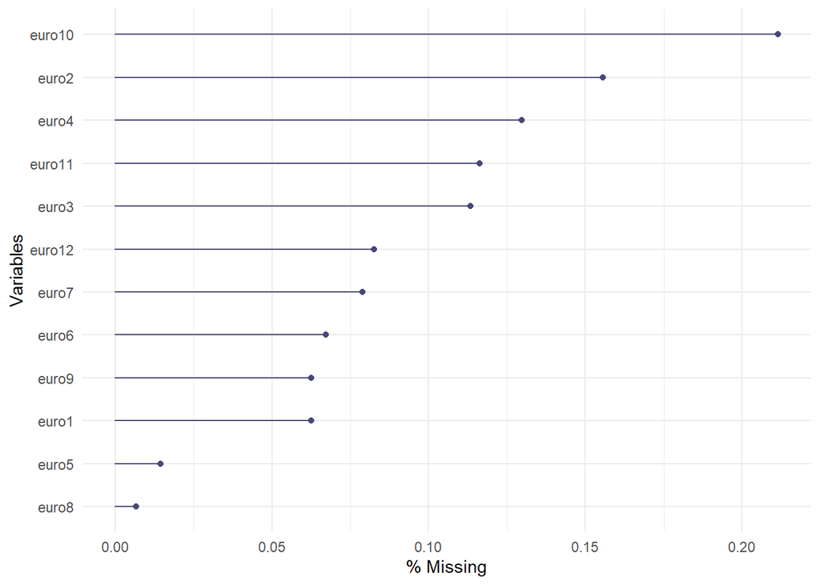

```r
eurod_items <-
  c(
    "Depressed mood",
    "Pessimism",
    "Wishing death",
    "Guilt",
    "Sleep",
    "Loss of interest",
    "Irritability",
    "Loss of appetite",
    "Fatigue",
    "Poor concentration",
    "Lack of enjoyment",
    "Tearfulness"
  )




share.data.first.interview %>%
     select(starts_with("euro") & !ends_with("_imp") & !ends_with("d") & !ends_with("cat")& !ends_with("f")) %>%
     gg_miss_var(show_pct = TRUE)
```

## 1.2 Univariate distribution of the EURO-D items

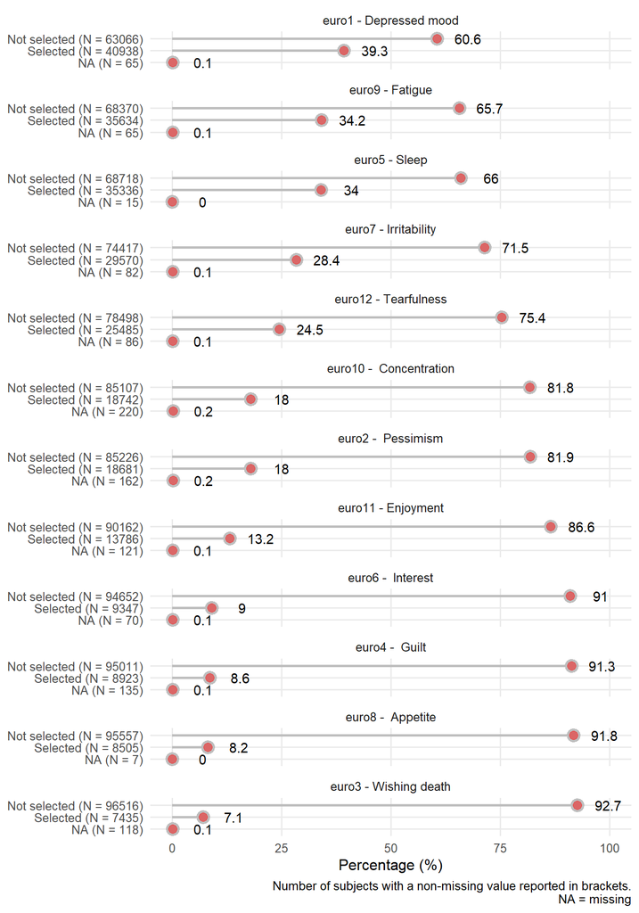

```r
share.data.first.interview %>%
  dplyr::select(euro1, euro2, euro3, euro4, euro5, euro6, euro7, euro8, euro9, euro10, euro11, euro12) %>%
  dplyr::mutate_all(forcats::as_factor) %>%
  dplyr::mutate_all(forcats::fct_explicit_na, "NA") %>%
  tidyr::pivot_longer(
    dplyr::everything(),
    names_to = "var",
    values_to = "value",
    values_drop_na = FALSE
  ) %>%
  dplyr::group_by(var, value) %>%
  dplyr::summarize(N = n()) %>%
  dplyr::mutate(
    freq = N / sum(N),
    pct = round((freq * 100), 1),
    axis_lab = paste0(value, ' ', '(N = ', N, ')'),
    var_label = case_when(var == "euro1" ~ "euro1 - Depressed mood",
                          var == "euro2" ~ "euro2 -  Pessimism",
                          var == "euro3" ~ "euro3 - Wishing death",
                          var == "euro4" ~ "euro4 -  Guilt",
                          var == "euro5" ~ "euro5 - Sleep",
                          var == "euro6" ~ "euro6 -  Interest",
                          var == "euro7" ~ "euro7 - Irritability",
                          var == "euro8" ~ "euro8 -  Appetite",
                          var == "euro9" ~ "euro9 - Fatigue",
                          var == "euro10" ~ "euro10 -  Concentration",
                          var == "euro11" ~ "euro11 - Enjoyment",
                          var == "euro12" ~ "euro12 - Tearfulness",

                          )
  ) -> a

tmp <- a %>% arrange(value, pct)
tmp$var_label <- factor(tmp$var_label, levels=tmp$var_label[1:12])

tmp %>%
  ggplot(aes(
    x = reorder(axis_lab, pct),
    y = pct,
    label = pct
  )) +
  geom_text(nudge_y = 7) +
  geom_pointrange(aes(ymin = 0, ymax = pct), alpha = 1, size = 1, color = "grey") +
  geom_point(color = "firebrick2",
             alpha = 0.6,
             size = 3) +
  ylab("Percentage (%)") +
  scale_y_continuous(limits = c(0, 100)) +
  labs(caption = "Number of subjects with a non-missing value reported in brackets.\nNA = missing") +
  facet_wrap(~ var_label, ncol = 1, scales = "free_y") +
  coord_flip() +
  theme_minimal(base_size = 12) +
  theme(axis.title.y = element_blank(),
        panel.grid.minor = element_blank())
```

The percentage of participants that selected individual symptom ranged from 7% (wishing death) to 39% (depressed mood).

## 1.3 Multivariate analysis

Correlations between EURO-D items

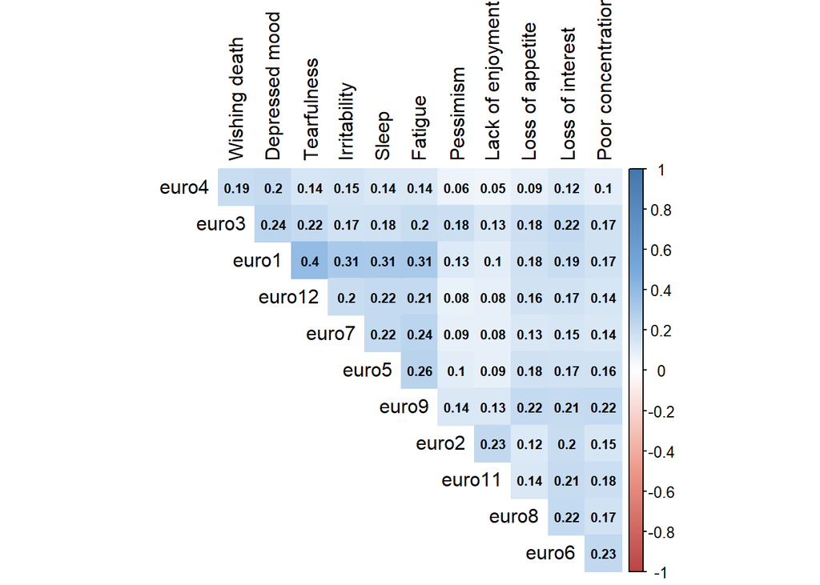

```r
corrs <- share.data.first.interview %>%
  dplyr::select(euro1, euro2, euro3, euro4, euro5, euro6, euro7, euro8, euro9, euro10, euro11, euro12 ) %>%
  filter(complete.cases(.)) %>%
  dplyr::mutate_all(as.numeric)

M <- cor(corrs)
col <- colorRampPalette(c("#BB4444", "#EE9988", "#FFFFFF", "#77AADD", "#4477AA"))
colnames(M) <- eurod_items
corrplot(M, method = "color", col = col(200),
         type = "upper", order = "hclust", number.cex = .7,
         addCoef.col = "black", # Add coefficient of correlation
         tl.col = "black", tl.srt = 90, # Text label color and rotation
         # hide correlation coefficient on the principal diagonal
         diag = FALSE)
```

Consistent with the knowledge about the correlation between items, wishing death, depressed mood and tearfulness (affective suffering factor) were positively correlated, as poor concentration, loss of interest and lack of enjoyment (motivation factor) - which had high correlation also with loss of appetite.

Clustering symptoms, using binary distance

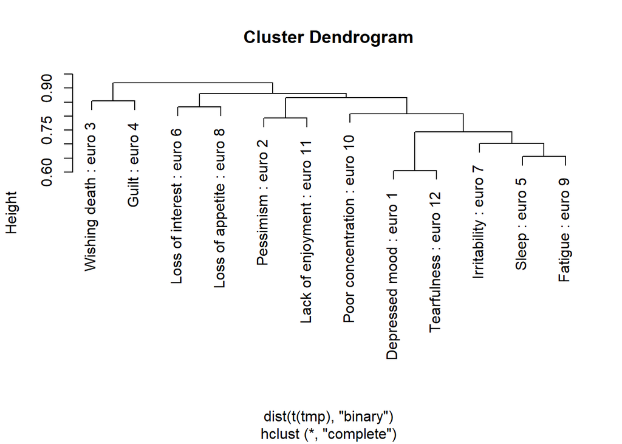

```r
#convert to 1/0 Selected/Not selected items
tmp <- select(share.data.first.interview, starts_with("euro") & !starts_with("eurod")) %>% mutate_all(funs(as.numeric(as.factor(.))))
tmp <- tmp-1
#plot(hclust(dist(t(tmp), "binary")))


plot(hclust(dist(t(tmp), "binary")), labels = paste(eurod_items, ": euro", 1:12))
```

# 2 Statistical modelling of the 12 depressive symptoms in EURO-D

## 2.1 Additional descriptive statistics for the 12 symptoms by the pivotal variables

### 2.1.1 Symptoms by gender

```r
s0 <-   Hmisc::summaryM(
        euro1 + euro2+ euro2 + euro3 + euro4 + euro5 + euro6 + euro7 + euro8 + euro9 + euro10 + euro11 + euro12  ~ gender,
        data = share.data.first.interview,
        overall = FALSE,
        test = FALSE
    )

Hmisc::html(
    s0,
    caption = 'Symptom response by gender',
    exclude1 = TRUE,
    npct = 'both',
    digits = 3,
    prmsd = TRUE,
    brmsd = TRUE,
    msdsize = mu$smaller2
)
```

| Symptom response by gender. | Symptom response by gender. N | Symptom response by gender. Male *N=47887* | Symptom response by gender. Female *N=56182* |
| --- | --- | --- | --- |
| euro1 : Selected | 104004 | 0.30 <sup>14400</sup>/<sub>47849</sub> | 0.47 <sup>26538</sup>/<sub>56155</sub> |
| euro2 : Selected | 103907 | 0.18 <sup>8372</sup>/<sub>47805</sub> | 0.18 <sup>10309</sup>/<sub>56102</sub> |
| euro3 : Selected | 103951 | 0.05 <sup>2499</sup>/<sub>47830</sub> | 0.09 <sup>4936</sup>/<sub>56121</sub> |
| euro4 : Selected | 103934 | 0.07 <sup>3113</sup>/<sub>47821</sub> | 0.10 <sup>5810</sup>/<sub>56113</sub> |
| euro5 : Selected | 104054 | 0.25 <sup>12198</sup>/<sub>47876</sub> | 0.41 <sup>23138</sup>/<sub>56178</sub> |
| euro6 : Selected | 103999 | 0.08 <sup>3760</sup>/<sub>47858</sub> | 0.10 <sup>5587</sup>/<sub>56141</sub> |
| euro7 : Selected | 103987 | 0.27 <sup>13107</sup>/<sub>47852</sub> | 0.29 <sup>16463</sup>/<sub>56135</sub> |
| euro8 : Selected | 104062 | 0.06 <sup>3044</sup>/<sub>47886</sub> | 0.10 <sup>5461</sup>/<sub>56176</sub> |
| euro9 : Selected | 104004 | 0.29 <sup>13832</sup>/<sub>47854</sub> | 0.39 <sup>21802</sup>/<sub>56150</sub> |
| euro10 : Selected | 103849 | 0.17 <sup>8021</sup>/<sub>47794</sub> | 0.19 <sup>10721</sup>/<sub>56055</sub> |
| euro11 : Selected | 103948 | 0.13 <sup>6234</sup>/<sub>47817</sub> | 0.13 <sup>7552</sup>/<sub>56131</sub> |
| euro12 : Selected | 103983 | 0.11 <sup>5440</sup>/<sub>47850</sub> | 0.36 <sup>20045</sup>/<sub>56133</sub> |

*N* is the number of non-missing values.

```r
#saving the table for the paper
tex.table <- latex(
    s0, digits=2, what="%", file="out/TableSymptomsOverall.tex")
```

### 2.1.2 Symptoms by region and gender

```r
s0 <-   Hmisc::summaryM(
        euro1 + euro2+ euro2 + euro3 + euro4 + euro5 + euro6 + euro7 + euro8 + euro9 + euro10 + euro11 + euro12  ~ gender,
        data = share.data.first.interview,
        overall = FALSE,
        test = FALSE
    )

s <-
    Hmisc::summaryM(
        euro1 + euro2+ euro2 + euro3 + euro4 + euro5 + euro6 + euro7 + euro8 + euro9 + euro10 + euro11 + euro12  ~ gender + region,
        data = share.data.first.interview,
        overall = FALSE,
        test = FALSE
    )

Hmisc::html(
    s,
    caption = 'Item response by gender and region',
    exclude1 = TRUE,
    npct = 'both',
    digits = 3,
    prmsd = TRUE,
    brmsd = TRUE,
    msdsize = mu$smaller2
)
```

| Item response by gender and region. | Item response by gender and region. N | Item response by gender and region. Male *N=11957* | Item response by gender and region. Female *N=15473* |
| --- | --- | --- | --- |
| Northern |  |  |  |
| euro1 : Selected | 11254 | 0.23 <sup>1255</sup>/<sub>5383</sub> | 0.38 <sup>2260</sup>/<sub>5871</sub> |
| euro2 : Selected | 11243 | 0.06 <sup>326</sup>/<sub>5377</sub> | 0.05 <sup>306</sup>/<sub>5866</sub> |
| euro3 : Selected | 11247 | 0.03 <sup>143</sup>/<sub>5382</sub> | 0.05 <sup>269</sup>/<sub>5865</sub> |
| euro4 : Selected | 11247 | 0.06 <sup>327</sup>/<sub>5380</sub> | 0.12 <sup>680</sup>/<sub>5867</sub> |
| euro5 : Selected | 11257 | 0.23 <sup>1222</sup>/<sub>5384</sub> | 0.38 <sup>2241</sup>/<sub>5873</sub> |
| euro6 : Selected | 11252 | 0.06 <sup>303</sup>/<sub>5383</sub> | 0.07 <sup>402</sup>/<sub>5869</sub> |
| euro7 : Selected | 11253 | 0.21 <sup>1111</sup>/<sub>5381</sub> | 0.23 <sup>1339</sup>/<sub>5872</sub> |
| euro8 : Selected | 11258 | 0.05 <sup>262</sup>/<sub>5385</sub> | 0.08 <sup>443</sup>/<sub>5873</sub> |
| euro9 : Selected | 11252 | 0.29 <sup>1572</sup>/<sub>5383</sub> | 0.36 <sup>2094</sup>/<sub>5869</sub> |
| euro10 : Selected | 11240 | 0.12 <sup>652</sup>/<sub>5377</sub> | 0.11 <sup>648</sup>/<sub>5863</sub> |
| euro11 : Selected | 11250 | 0.09 <sup>504</sup>/<sub>5379</sub> | 0.08 <sup>452</sup>/<sub>5871</sub> |
| euro12 : Selected | 11251 | 0.10 <sup>559</sup>/<sub>5385</sub> | 0.28 <sup>1646</sup>/<sub>5866</sub> |
| Western |  |  |  |
| euro1 : Selected | 42608 | 0.31 <sup>6108</sup>/<sub>19860</sub> | 0.47 <sup>10771</sup>/<sub>22748</sub> |
| euro2 : Selected | 42572 | 0.12 <sup>2429</sup>/<sub>19843</sub> | 0.12 <sup>2798</sup>/<sub>22729</sub> |
| euro3 : Selected | 42587 | 0.06 <sup>1119</sup>/<sub>19853</sub> | 0.09 <sup>2071</sup>/<sub>22734</sub> |
| euro4 : Selected | 42587 | 0.06 <sup>1213</sup>/<sub>19853</sub> | 0.10 <sup>2293</sup>/<sub>22734</sub> |
| euro5 : Selected | 42627 | 0.26 <sup>5073</sup>/<sub>19870</sub> | 0.40 <sup>9134</sup>/<sub>22757</sub> |
| euro6 : Selected | 42607 | 0.06 <sup>1181</sup>/<sub>19863</sub> | 0.07 <sup>1602</sup>/<sub>22744</sub> |
| euro7 : Selected | 42588 | 0.26 <sup>5099</sup>/<sub>19857</sub> | 0.26 <sup>6012</sup>/<sub>22731</sub> |
| euro8 : Selected | 42628 | 0.06 <sup>1158</sup>/<sub>19872</sub> | 0.09 <sup>1997</sup>/<sub>22756</sub> |
| euro9 : Selected | 42611 | 0.26 <sup>5218</sup>/<sub>19861</sub> | 0.35 <sup>7940</sup>/<sub>22750</sub> |
| euro10 : Selected | 42579 | 0.17 <sup>3430</sup>/<sub>19849</sub> | 0.18 <sup>4148</sup>/<sub>22730</sub> |
| euro11 : Selected | 42598 | 0.12 <sup>2334</sup>/<sub>19857</sub> | 0.12 <sup>2665</sup>/<sub>22741</sub> |
| euro12 : Selected | 42598 | 0.13 <sup>2645</sup>/<sub>19857</sub> | 0.36 <sup>8253</sup>/<sub>22741</sub> |
| Southern |  |  |  |
| euro1 : Selected | 22738 | 0.27 <sup>2873</sup>/<sub>10664</sub> | 0.47 <sup>5627</sup>/<sub>12074</sub> |
| euro2 : Selected | 22710 | 0.22 <sup>2392</sup>/<sub>10654</sub> | 0.25 <sup>3008</sup>/<sub>12056</sub> |
| euro3 : Selected | 22723 | 0.04 <sup>463</sup>/<sub>10660</sub> | 0.08 <sup>990</sup>/<sub>12063</sub> |
| euro4 : Selected | 22705 | 0.06 <sup>649</sup>/<sub>10649</sub> | 0.09 <sup>1036</sup>/<sub>12056</sub> |
| euro5 : Selected | 22744 | 0.20 <sup>2180</sup>/<sub>10669</sub> | 0.37 <sup>4508</sup>/<sub>12075</sub> |
| euro6 : Selected | 22724 | 0.11 <sup>1214</sup>/<sub>10660</sub> | 0.16 <sup>1986</sup>/<sub>12064</sub> |
| euro7 : Selected | 22736 | 0.29 <sup>3090</sup>/<sub>10667</sub> | 0.31 <sup>3798</sup>/<sub>12069</sub> |
| euro8 : Selected | 22746 | 0.07 <sup>773</sup>/<sub>10672</sub> | 0.12 <sup>1490</sup>/<sub>12074</sub> |
| euro9 : Selected | 22743 | 0.27 <sup>2903</sup>/<sub>10670</sub> | 0.40 <sup>4851</sup>/<sub>12073</sub> |
| euro10 : Selected | 22671 | 0.21 <sup>2208</sup>/<sub>10642</sub> | 0.28 <sup>3381</sup>/<sub>12029</sub> |
| euro11 : Selected | 22703 | 0.16 <sup>1756</sup>/<sub>10644</sub> | 0.21 <sup>2483</sup>/<sub>12059</sub> |
| euro12 : Selected | 22731 | 0.12 <sup>1259</sup>/<sub>10661</sub> | 0.41 <sup>4966</sup>/<sub>12070</sub> |
| Eastern |  |  |  |
| euro1 : Selected | 27404 | 0.35 <sup>4164</sup>/<sub>11942</sub> | 0.51 <sup>7880</sup>/<sub>15462</sub> |
| euro2 : Selected | 27382 | 0.27 <sup>3225</sup>/<sub>11931</sub> | 0.27 <sup>4197</sup>/<sub>15451</sub> |
| euro3 : Selected | 27394 | 0.06 <sup>774</sup>/<sub>11935</sub> | 0.10 <sup>1606</sup>/<sub>15459</sub> |
| euro4 : Selected | 27395 | 0.08 <sup>924</sup>/<sub>11939</sub> | 0.12 <sup>1801</sup>/<sub>15456</sub> |
| euro5 : Selected | 27426 | 0.31 <sup>3723</sup>/<sub>11953</sub> | 0.47 <sup>7255</sup>/<sub>15473</sub> |
| euro6 : Selected | 27416 | 0.09 <sup>1062</sup>/<sub>11952</sub> | 0.10 <sup>1597</sup>/<sub>15464</sub> |
| euro7 : Selected | 27410 | 0.32 <sup>3807</sup>/<sub>11947</sub> | 0.34 <sup>5314</sup>/<sub>15463</sub> |
| euro8 : Selected | 27430 | 0.07 <sup>851</sup>/<sub>11957</sub> | 0.10 <sup>1531</sup>/<sub>15473</sub> |
| euro9 : Selected | 27398 | 0.35 <sup>4139</sup>/<sub>11940</sub> | 0.45 <sup>6917</sup>/<sub>15458</sub> |
| euro10 : Selected | 27359 | 0.15 <sup>1731</sup>/<sub>11926</sub> | 0.16 <sup>2544</sup>/<sub>15433</sub> |
| euro11 : Selected | 27397 | 0.14 <sup>1640</sup>/<sub>11937</sub> | 0.13 <sup>1952</sup>/<sub>15460</sub> |
| euro12 : Selected | 27403 | 0.08 <sup>977</sup>/<sub>11947</sub> | 0.34 <sup>5180</sup>/<sub>15456</sub> |

*N* is the number of non-missing values.

```r
#saving the table for the paper
tex.table <- latex(
    s, digits=2, what="%", file="out/TableItems.tex")
```

## 2.2 Model fitting

As in the analysis for EURO-D we fitted types of models to each of 12 depressive symptoms of the EURO-D scale. For cease of comparison the EURO-D models are included first.

- **unadjusted models**: including two-way interactions between age, gender and geographic region (unadjusted models)
- **adjusted models**: in addition to age, gender, and region as in the “unadjusted models” further adjusting by known risk factors (education, BMI, smoking, presence of chronic disease, vigorous physical activity, living arrangement)

Age was centered at 50 years and modeled - as a **linear** effect - as a **non-linear** effect with restricted cubic splines (rcs) and 5 knots placed at ages: 51, 56, 62, 70 and 81, using the default choice for the quantiles

```r
#definition of standardized age for ease of interpretation of the coefficients
share.data.first.interview<- share.data.first.interview %>% mutate (age_int_stand = age_int - 50)
```

The country of residence was modeled by grouping the countries into four **geographic regions**

Some of the coefficients of the estimated model are difficult to interpret, due to the use of restricted cubic splines and of interactions. Therefore, graphical displays of the estimated probabilities are used to present the results, rather than a table with the estimated coefficients. When RCS are used, the estimated coefficients/odds ration (OR) are not presented only age and its interactions.

The models that use age as a linear term are fitted with the aim of evaluating the impact of choice on the estimated results.

First we create the labels for the symptoms and standardize BMI to 10 unit differences.

```r
eurod_items <-
  c(
    "Depressed mood",
    "Pessimism",
    "Wishing death",
    "Guilt",
    "Sleep",
    "Loss of interest",
    "Irritability",
    "Loss of appetite",
    "Fatigue",
    "Poor concentration",
    "Lack of enjoyment",
    "Tearfulness"
  )


eurod_items_2names <- paste0("euro", 1:12, " - ", eurod_items)
eurod_items_labs <- paste0("euro", 1:12, "\n", eurod_items)


# standardization of bmi to 10 unit differences
share.data.first.interview$bmi_imp <- share.data.first.interview$bmi_imp/10
data.grid.adj.region$bmi_imp <- data.grid.adj.region$bmi_imp/10


#creates the figures subdirectory if it does not exist
if (!file.exists("figures")) dir.create("figures")
```

### 2.2.1 Item 1 - Depressed mood

#### 2.2.1.1 Unadjusted model with rcs for age

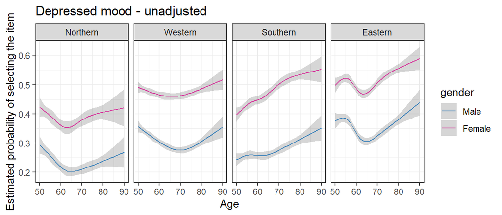

```r
i <- 1

share.data.first.interview$y <- share.data.first.interview$euro1

my.mod2 <- glm(y ~ age1 + age2 + age3 + age4 + gender + region +
                      age1:region + age2:region + age3:region + age4:region +
                       age1:gender + age2:gender + age3:gender + age4:gender +
                       gender:region ,
                        data=share.data.first.interview, family="binomial",  x=TRUE, y=TRUE)



my.mod1 <- glm(y ~ rcspline.eval(age_int_stand, knots=Knots, inclx = TRUE)  + gender + region +
                      rcspline.eval(age_int_stand, knots=Knots, inclx = TRUE):region +
                       rcspline.eval(age_int_stand, knots=Knots, inclx = TRUE):gender +
                       gender:region ,
                        data=share.data.first.interview, family="binomial",  x=TRUE, y=TRUE)



my.pred <- predict(my.mod2, newdata=data.grid.region, se.fit = TRUE, type="response")


my.pred.all <- cbind.data.frame(data.grid.region, my.pred)
#my.pred.all <- mutate(my.pred.all, item = paste0("eurod", i))
my.pred.all$item <- eurod_items[i]
pred.items.unadj.region <- my.pred.all


ggplot(my.pred.all, aes(age1 + 50, fit, color=gender)) + geom_line() + facet_wrap(region~., ncol=4) + labs(x="Age", y="Estimated probability of selecting the item") + scale_color_manual(values=c("#4699dd","#ff3db7" )) + ggtitle(paste(eurod_items[i], "- unadjusted")) + theme_bw()  +
   geom_ribbon(aes(ymin = fit - 1.96*se.fit, ymax = fit + 1.96*se.fit), alpha = 0.2, linetype=0)
```

```r
ggsave(paste0("eurod", i, "_region_Unadj.png"), device="png", path = "figures" , height = 4, width=10)

anova(my.mod1, test="Chi")
```

```
## Analysis of Deviance Table
##
## Model: binomial, link: logit
##
## Response: y
##
## Terms added sequentially (first to last)
##
##
##                                                                  Df Deviance
## NULL
## rcspline.eval(age_int_stand, knots = Knots, inclx = TRUE)         4      162
## gender                                                            1     3188
## region                                                            3      548
## rcspline.eval(age_int_stand, knots = Knots, inclx = TRUE):region 12      150
## rcspline.eval(age_int_stand, knots = Knots, inclx = TRUE):gender  4       45
## gender:region                                                     3       35
##                                                                  Resid. Df
## NULL                                                                104003
## rcspline.eval(age_int_stand, knots = Knots, inclx = TRUE)           103999
## gender                                                              103998
## region                                                              103995
## rcspline.eval(age_int_stand, knots = Knots, inclx = TRUE):region    103983
## rcspline.eval(age_int_stand, knots = Knots, inclx = TRUE):gender    103979
## gender:region                                                       103976
##                                                                  Resid. Dev
## NULL                                                                 139436
## rcspline.eval(age_int_stand, knots = Knots, inclx = TRUE)            139274
## gender                                                               136086
## region                                                               135538
## rcspline.eval(age_int_stand, knots = Knots, inclx = TRUE):region     135388
## rcspline.eval(age_int_stand, knots = Knots, inclx = TRUE):gender     135344
## gender:region                                                        135309
##                                                                  Pr(>Chi)
## NULL
## rcspline.eval(age_int_stand, knots = Knots, inclx = TRUE)         < 2e-16 ***
## gender                                                            < 2e-16 ***
## region                                                            < 2e-16 ***
## rcspline.eval(age_int_stand, knots = Knots, inclx = TRUE):region  < 2e-16 ***
## rcspline.eval(age_int_stand, knots = Knots, inclx = TRUE):gender  4.9e-09 ***
## gender:region                                                     1.4e-07 ***
## ---
## Signif. codes:  0 '***' 0.001 '**' 0.01 '*' 0.05 '.' 0.1 ' ' 1
```

```r
OR3 <- vector("list", 12)
OR2 <- vector("list", 12)
```

#### 2.2.1.2 Adjusted model with rcs for age

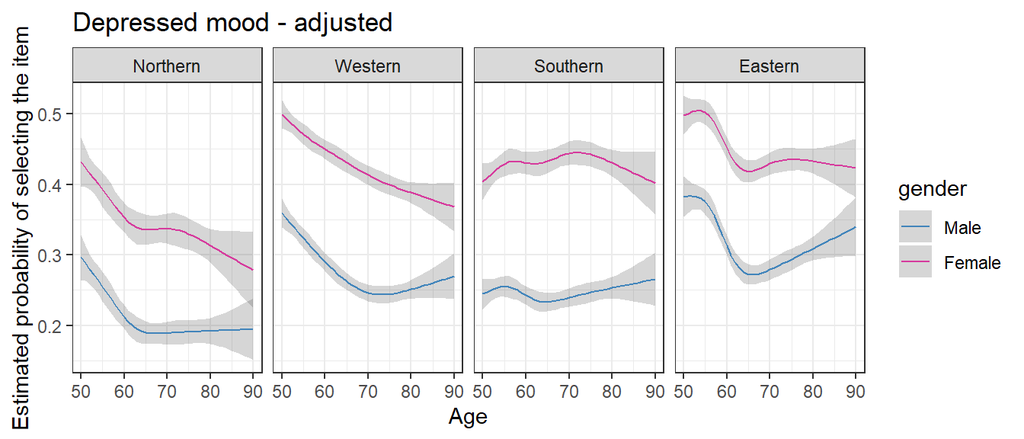

```r
my.mod1 <- glm(y ~ rcs(age_int) + gender + region +
                       rcs(age_int):region + rcs(age_int):gender + gender:region +
                       bmi_imp +  education_imp + cusmoke_imp + dis_chronic_pres +
                        pa_vig + living_arrangement,
                       data=share.data.first.interview, family="binomial",  x=TRUE, y=TRUE)


my.mod2 <- glm(y ~ age1 + age2 + age3 + age4 + gender + region +
                      age1:region + age2:region + age3:region + age4:region +
                       age1:gender + age2:gender + age3:gender + age4:gender +
                       gender:region +
                 bmi_imp + education_imp + cusmoke_imp + dis_chronic_pres +
                        pa_vig + living_arrangement,
                        data=share.data.first.interview, family="binomial",  x=TRUE, y=TRUE)

my.pred <- predict(my.mod2, newdata=data.grid.adj.region, se.fit = TRUE, type="response")


my.pred.all <- cbind.data.frame(data.grid.adj.region, my.pred)
#my.pred.all <- mutate(my.pred.all, item = paste0("eurod", i))
my.pred.all$item <- eurod_items[i]
pred.items.adj.region <- my.pred.all

ggplot(my.pred.all, aes(age1 + 50, fit, color=gender)) + geom_line() + facet_wrap(region~., ncol=4) + labs(x="Age", y="Estimated probability of selecting the item") + scale_color_manual(values=c("#4699dd","#ff3db7" )) + ggtitle(paste(eurod_items[i], "- adjusted")) +  theme_bw()  +
   geom_ribbon(aes(ymin = fit - 1.96*se.fit, ymax = fit + 1.96*se.fit), alpha = 0.2, linetype=0)
```

```r
ggsave(paste0("eurod", i, "_region_Adj.png"), device="png", path = "figures" , height = 4, width=10)

anova(my.mod1, test="Chi")
```

```
## Analysis of Deviance Table
##
## Model: binomial, link: logit
##
## Response: y
##
## Terms added sequentially (first to last)
##
##
##                     Df Deviance Resid. Df Resid. Dev Pr(>Chi)
## NULL                               104003     139436
## rcs(age_int)         4      162    103999     139274  < 2e-16 ***
## gender               1     3188    103998     136086  < 2e-16 ***
## region               3      548    103995     135538  < 2e-16 ***
## bmi_imp              1      105    103994     135433  < 2e-16 ***
## education_imp        3       70    103991     135363  4.3e-15 ***
## cusmoke_imp          1      110    103990     135253  < 2e-16 ***
## dis_chronic_pres     2     1336    103988     133917  < 2e-16 ***
## pa_vig               3      464    103985     133453  < 2e-16 ***
## living_arrangement   1      648    103984     132805  < 2e-16 ***
## rcs(age_int):region 12      130    103972     132674  < 2e-16 ***
## rcs(age_int):gender  4       27    103968     132647  1.9e-05 ***
## gender:region        3       48    103965     132599  2.1e-10 ***
## ---
## Signif. codes:  0 '***' 0.001 '**' 0.01 '*' 0.05 '.' 0.1 ' ' 1
```

```r
OR3[[i]] <- get.OR3(my.mod1, names.var = c(1:9, "BMI", "Education : Medium","Education : High", "Education : Other","Current smoking : Yes", "Chronic diseases : 1" , "Chronic diseases: 2+", "Vigorous PA : Once a week", "Vigorous PA : 1−3 times a month", "Vigorous PA : Hardly ever, or never", "Living alone : Yes", 21:39))[10:20,]

OR2[[i]] <- get.OR2(my.mod1, names.var = c(1:9, "BMI", "Education : Medium","Education : High", "Education : Other","Current smoking : Yes", "Chronic diseases : 1" , "Chronic diseases: 2+", "Vigorous PA : Once a week", "Vigorous PA : 1−3 times a month", "Vigorous PA : Hardly ever, or never", "Living alone : Yes", 21:39))[10:20,]

kable(OR3[[i]], caption=paste(eurod_items_2names[i], "- OR for the risk factors"))
```

euro1 - Depressed mood - OR for the risk factors

|  | OR | 95% CI | P |
| --- | --- | --- | --- |
| BMI | 1.01 | 0.98-1.04 | 0.53 |
| Education : Medium | 0.94 | 0.91-0.97 | <0.01 |
| Education : High | 0.95 | 0.92-0.99 | 0.01 |
| Education : Other | 1.07 | 0.88-1.3 | 0.49 |
| Current smoking : Yes | 1.14 | 1.1-1.17 | <0.01 |
| Chronic diseases : 1 | 1.29 | 1.25-1.33 | <0.01 |
| Chronic diseases: 2+ | 1.90 | 1.83-1.98 | <0.01 |
| Vigorous PA : Once a week | 0.95 | 0.91-0.99 | 0.01 |
| Vigorous PA : 1-3 times a month | 0.98 | 0.94-1.03 | 0.45 |
| Vigorous PA : Hardly ever, or never | 1.32 | 1.28-1.36 | <0.01 |
| Living alone : Yes | 1.46 | 1.42-1.5 | <0.01 |

### 2.2.2 Item 2 - Pessimism

#### 2.2.2.1 Unadjusted model with rcs for age

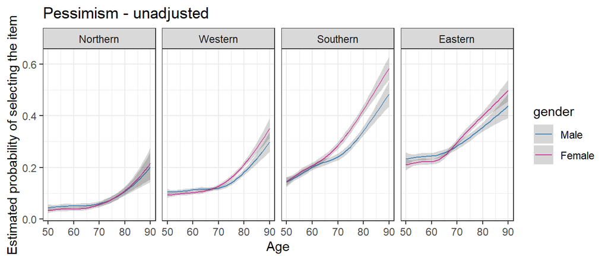

```r
i <- i+1

share.data.first.interview$y <- share.data.first.interview$euro2

my.mod2 <- glm(y ~ age1 + age2 + age3 + age4 + gender + region +
                      age1:region + age2:region + age3:region + age4:region +
                       age1:gender + age2:gender + age3:gender + age4:gender +
                       gender:region ,
                        data=share.data.first.interview, family="binomial",  x=TRUE, y=TRUE)



my.mod1 <- glm(y ~ rcspline.eval(age_int_stand, knots=Knots, inclx = TRUE)  + gender + region +
                      rcspline.eval(age_int_stand, knots=Knots, inclx = TRUE):region +
                       rcspline.eval(age_int_stand, knots=Knots, inclx = TRUE):gender +
                       gender:region ,
                        data=share.data.first.interview, family="binomial",  x=TRUE, y=TRUE)



my.pred <- predict(my.mod2, newdata=data.grid.region, se.fit = TRUE, type="response")


my.pred.all <- cbind.data.frame(data.grid.region, my.pred)
my.pred.all$item <- eurod_items[i]

#saving the prediction for the items
pred.items.unadj.region <- rbind.data.frame(pred.items.unadj.region, my.pred.all)

ggplot(my.pred.all, aes(age1 + 50, fit, color=gender)) + geom_line() + facet_wrap(region~., ncol=4) + labs(x="Age", y="Estimated probability of selecting the item") + scale_color_manual(values=c("#4699dd","#ff3db7" )) + ggtitle(paste(eurod_items[i], "- unadjusted")) + theme_bw()  +
   geom_ribbon(aes(ymin = fit - 1.96*se.fit, ymax = fit + 1.96*se.fit), alpha = 0.2, linetype=0)
```

```r
ggsave(paste0("eurod", i, "_region_Unadj.png"), device="png", path = "figures" , height = 4, width=10)

anova(my.mod1, test="Chi")
```

```
## Analysis of Deviance Table
##
## Model: binomial, link: logit
##
## Response: y
##
## Terms added sequentially (first to last)
##
##
##                                                                  Df Deviance
## NULL
## rcspline.eval(age_int_stand, knots = Knots, inclx = TRUE)         4     1808
## gender                                                            1       12
## region                                                            3     4273
## rcspline.eval(age_int_stand, knots = Knots, inclx = TRUE):region 12       81
## rcspline.eval(age_int_stand, knots = Knots, inclx = TRUE):gender  4       58
## gender:region                                                     3       23
##                                                                  Resid. Df
## NULL                                                                103906
## rcspline.eval(age_int_stand, knots = Knots, inclx = TRUE)           103902
## gender                                                              103901
## region                                                              103898
## rcspline.eval(age_int_stand, knots = Knots, inclx = TRUE):region    103886
## rcspline.eval(age_int_stand, knots = Knots, inclx = TRUE):gender    103882
## gender:region                                                       103879
##                                                                  Resid. Dev
## NULL                                                                  97895
## rcspline.eval(age_int_stand, knots = Knots, inclx = TRUE)             96087
## gender                                                                96075
## region                                                                91802
## rcspline.eval(age_int_stand, knots = Knots, inclx = TRUE):region      91721
## rcspline.eval(age_int_stand, knots = Knots, inclx = TRUE):gender      91663
## gender:region                                                         91640
##                                                                  Pr(>Chi)
## NULL
## rcspline.eval(age_int_stand, knots = Knots, inclx = TRUE)         < 2e-16 ***
## gender                                                            0.00047 ***
## region                                                            < 2e-16 ***
## rcspline.eval(age_int_stand, knots = Knots, inclx = TRUE):region  2.5e-12 ***
## rcspline.eval(age_int_stand, knots = Knots, inclx = TRUE):gender  8.1e-12 ***
## gender:region                                                     3.3e-05 ***
## ---
## Signif. codes:  0 '***' 0.001 '**' 0.01 '*' 0.05 '.' 0.1 ' ' 1
```

#### 2.2.2.2 Adjusted model with rcs for age

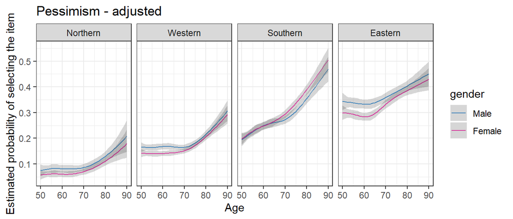

```r
my.mod1 <- glm(y ~ rcs(age_int) + gender + region +
                       rcs(age_int):region + rcs(age_int):gender + gender:region +
                       bmi_imp +  education_imp + cusmoke_imp + dis_chronic_pres +
                        pa_vig + living_arrangement,
                       data=share.data.first.interview, family="binomial",  x=TRUE, y=TRUE)


my.mod2 <- glm(y ~ age1 + age2 + age3 + age4 + gender + region +
                      age1:region + age2:region + age3:region + age4:region +
                       age1:gender + age2:gender + age3:gender + age4:gender +
                       gender:region +
                 bmi_imp + education_imp + cusmoke_imp + dis_chronic_pres +
                        pa_vig + living_arrangement,
                        data=share.data.first.interview, family="binomial",  x=TRUE, y=TRUE)

my.pred <- predict(my.mod2, newdata=data.grid.adj.region, se.fit = TRUE, type="response")


my.pred.all <- cbind.data.frame(data.grid.adj.region, my.pred)
my.pred.all$item <- eurod_items[i]

#saving the prediction for the items
pred.items.adj.region <- rbind.data.frame(pred.items.adj.region, my.pred.all)


ggplot(my.pred.all, aes(age1 + 50, fit, color=gender)) + geom_line() + facet_wrap(region~., ncol=4) + labs(x="Age", y="Estimated probability of selecting the item") + scale_color_manual(values=c("#4699dd","#ff3db7" )) + ggtitle(paste(eurod_items[i], "- adjusted")) +  theme_bw()  +
   geom_ribbon(aes(ymin = fit - 1.96*se.fit, ymax = fit + 1.96*se.fit), alpha = 0.2, linetype=0)
```

```r
ggsave(paste0("eurod", i, "_region_Adj.png"), device="png", path = "figures" , height = 4, width=10)

anova(my.mod1, test="Chi")
```

```
## Analysis of Deviance Table
##
## Model: binomial, link: logit
##
## Response: y
##
## Terms added sequentially (first to last)
##
##
##                     Df Deviance Resid. Df Resid. Dev Pr(>Chi)
## NULL                               103906      97895
## rcs(age_int)         4     1808    103902      96087  < 2e-16 ***
## gender               1       12    103901      96075  0.00047 ***
## region               3     4273    103898      91802  < 2e-16 ***
## bmi_imp              1       65    103897      91738  9.5e-16 ***
## education_imp        3      766    103894      90972  < 2e-16 ***
## cusmoke_imp          1      104    103893      90868  < 2e-16 ***
## dis_chronic_pres     2      213    103891      90655  < 2e-16 ***
## pa_vig               3      826    103888      89829  < 2e-16 ***
## living_arrangement   1      308    103887      89521  < 2e-16 ***
## rcs(age_int):region 12       73    103875      89448  8.6e-11 ***
## rcs(age_int):gender  4       13    103871      89435  0.01174 *
## gender:region        3       36    103868      89399  8.1e-08 ***
## ---
## Signif. codes:  0 '***' 0.001 '**' 0.01 '*' 0.05 '.' 0.1 ' ' 1
```

```r
OR3[[i]] <- get.OR3(my.mod1, names.var = c(1:9, "BMI", "Education : Medium","Education : High", "Education : Other","Current smoking : Yes", "Chronic diseases : 1" , "Chronic diseases: 2+", "Vigorous PA : Once a week", "Vigorous PA : 1−3 times a month", "Vigorous PA : Hardly ever, or never", "Living alone : Yes", 21:39))[10:20,]

OR2[[i]] <- get.OR2(my.mod1, names.var = c(1:9, "BMI", "Education : Medium","Education : High", "Education : Other","Current smoking : Yes", "Chronic diseases : 1" , "Chronic diseases: 2+", "Vigorous PA : Once a week", "Vigorous PA : 1−3 times a month", "Vigorous PA : Hardly ever, or never", "Living alone : Yes", 21:39))[10:20,]

kable(OR3[[i]], caption=paste(eurod_items_2names[i], "- OR for the risk factors"))
```

euro2 - Pessimism - OR for the risk factors

|  | OR | 95% CI | P |
| --- | --- | --- | --- |
| BMI | 1.03 | 0.99-1.07 | 0.15 |
| Education : Medium | 0.69 | 0.66-0.72 | <0.01 |
| Education : High | 0.58 | 0.55-0.61 | <0.01 |
| Education : Other | 0.75 | 0.57-0.98 | 0.04 |
| Current smoking : Yes | 1.19 | 1.14-1.24 | <0.01 |
| Chronic diseases : 1 | 1.06 | 1.02-1.1 | <0.01 |
| Chronic diseases: 2+ | 1.27 | 1.22-1.33 | <0.01 |
| Vigorous PA : Once a week | 1.14 | 1.08-1.21 | <0.01 |
| Vigorous PA : 1-3 times a month | 1.26 | 1.18-1.34 | <0.01 |
| Vigorous PA : Hardly ever, or never | 1.77 | 1.7-1.85 | <0.01 |
| Living alone : Yes | 1.38 | 1.33-1.44 | <0.01 |

### 2.2.3 Item 3 - Wishing death

#### 2.2.3.1 Unadjusted model with rcs for age

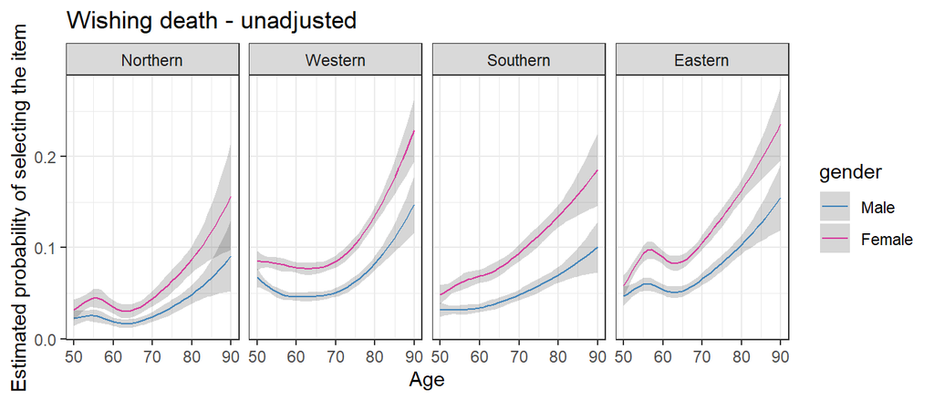

```r
i <- i+1

share.data.first.interview$y <- share.data.first.interview$euro3

my.mod2 <- glm(y ~ age1 + age2 + age3 + age4 + gender + region +
                      age1:region + age2:region + age3:region + age4:region +
                       age1:gender + age2:gender + age3:gender + age4:gender +
                       gender:region ,
                        data=share.data.first.interview, family="binomial",  x=TRUE, y=TRUE)



my.mod1 <- glm(y ~ rcspline.eval(age_int_stand, knots=Knots, inclx = TRUE)  + gender + region +
                      rcspline.eval(age_int_stand, knots=Knots, inclx = TRUE):region +
                       rcspline.eval(age_int_stand, knots=Knots, inclx = TRUE):gender +
                       gender:region ,
                        data=share.data.first.interview, family="binomial",  x=TRUE, y=TRUE)



my.pred <- predict(my.mod2, newdata=data.grid.region, se.fit = TRUE, type="response")


my.pred.all <- cbind.data.frame(data.grid.region, my.pred)
my.pred.all$item <- eurod_items[i]

#saving the prediction for the items
pred.items.unadj.region <- rbind.data.frame(pred.items.unadj.region, my.pred.all)

ggplot(my.pred.all, aes(age1 + 50, fit, color=gender)) + geom_line() + facet_wrap(region~., ncol=4) + labs(x="Age", y="Estimated probability of selecting the item") + scale_color_manual(values=c("#4699dd","#ff3db7" )) + ggtitle(paste(eurod_items[i], "- unadjusted")) + theme_bw()  +
   geom_ribbon(aes(ymin = fit - 1.96*se.fit, ymax = fit + 1.96*se.fit), alpha = 0.2, linetype=0)
```

```r
ggsave(paste0("eurod", i, "_region_Unadj.png"), device="png", path = "figures" , height = 4, width=10)

anova(my.mod1, test="Chi")
```

```
## Analysis of Deviance Table
##
## Model: binomial, link: logit
##
## Response: y
##
## Terms added sequentially (first to last)
##
##
##                                                                  Df Deviance
## NULL
## rcspline.eval(age_int_stand, knots = Knots, inclx = TRUE)         4      583
## gender                                                            1      495
## region                                                            3      341
## rcspline.eval(age_int_stand, knots = Knots, inclx = TRUE):region 12       66
## rcspline.eval(age_int_stand, knots = Knots, inclx = TRUE):gender  4        9
## gender:region                                                     3        8
##                                                                  Resid. Df
## NULL                                                                103950
## rcspline.eval(age_int_stand, knots = Knots, inclx = TRUE)           103946
## gender                                                              103945
## region                                                              103942
## rcspline.eval(age_int_stand, knots = Knots, inclx = TRUE):region    103930
## rcspline.eval(age_int_stand, knots = Knots, inclx = TRUE):gender    103926
## gender:region                                                       103923
##                                                                  Resid. Dev
## NULL                                                                  53548
## rcspline.eval(age_int_stand, knots = Knots, inclx = TRUE)             52965
## gender                                                                52469
## region                                                                52128
## rcspline.eval(age_int_stand, knots = Knots, inclx = TRUE):region      52062
## rcspline.eval(age_int_stand, knots = Knots, inclx = TRUE):gender      52053
## gender:region                                                         52045
##                                                                  Pr(>Chi)
## NULL
## rcspline.eval(age_int_stand, knots = Knots, inclx = TRUE)         < 2e-16 ***
## gender                                                            < 2e-16 ***
## region                                                            < 2e-16 ***
## rcspline.eval(age_int_stand, knots = Knots, inclx = TRUE):region  1.8e-09 ***
## rcspline.eval(age_int_stand, knots = Knots, inclx = TRUE):gender    0.062 .
## gender:region                                                       0.043 *
## ---
## Signif. codes:  0 '***' 0.001 '**' 0.01 '*' 0.05 '.' 0.1 ' ' 1
```

#### 2.2.3.2 Adjusted model with rcs for age

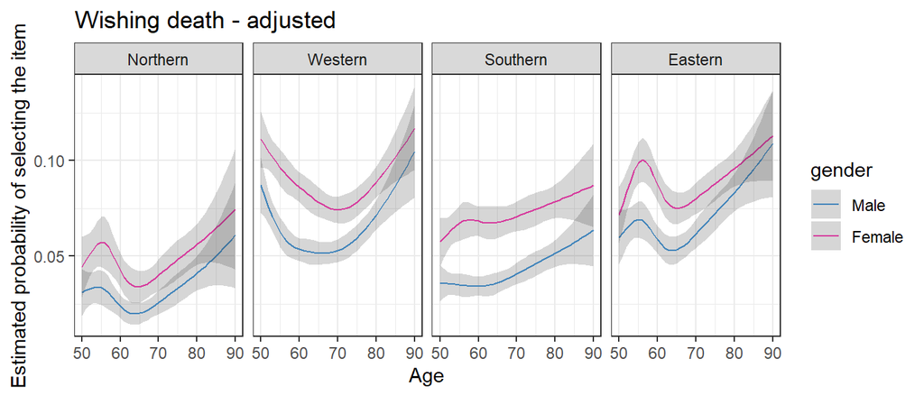

```r
my.mod1 <- glm(y ~ rcs(age_int) + gender + region +
                       rcs(age_int):region + rcs(age_int):gender + gender:region +
                       bmi_imp +  education_imp + cusmoke_imp + dis_chronic_pres +
                        pa_vig + living_arrangement,
                       data=share.data.first.interview, family="binomial",  x=TRUE, y=TRUE)


my.mod2 <- glm(y ~ age1 + age2 + age3 + age4 + gender + region +
                      age1:region + age2:region + age3:region + age4:region +
                       age1:gender + age2:gender + age3:gender + age4:gender +
                       gender:region +
                 bmi_imp + education_imp + cusmoke_imp + dis_chronic_pres +
                        pa_vig + living_arrangement,
                        data=share.data.first.interview, family="binomial",  x=TRUE, y=TRUE)

my.pred <- predict(my.mod2, newdata=data.grid.adj.region, se.fit = TRUE, type="response")


my.pred.all <- cbind.data.frame(data.grid.adj.region, my.pred)
my.pred.all$item <- eurod_items[i]

#saving the prediction for the items
pred.items.adj.region <- rbind.data.frame(pred.items.adj.region, my.pred.all)


ggplot(my.pred.all, aes(age1 + 50, fit, color=gender)) + geom_line() + facet_wrap(region~., ncol=4) + labs(x="Age", y="Estimated probability of selecting the item") + scale_color_manual(values=c("#4699dd","#ff3db7" )) + ggtitle(paste(eurod_items[i], "- adjusted")) +  theme_bw()  +
   geom_ribbon(aes(ymin = fit - 1.96*se.fit, ymax = fit + 1.96*se.fit), alpha = 0.2, linetype=0)
```

```r
ggsave(paste0("eurod", i, "_region_Adj.png"), device="png", path = "figures" , height = 4, width=10)

anova(my.mod1, test="Chi")
```

```
## Analysis of Deviance Table
##
## Model: binomial, link: logit
##
## Response: y
##
## Terms added sequentially (first to last)
##
##
##                     Df Deviance Resid. Df Resid. Dev Pr(>Chi)
## NULL                               103950      53548
## rcs(age_int)         4      583    103946      52965  < 2e-16 ***
## gender               1      495    103945      52469  < 2e-16 ***
## region               3      341    103942      52128  < 2e-16 ***
## bmi_imp              1       70    103941      52057  < 2e-16 ***
## education_imp        3      450    103938      51607  < 2e-16 ***
## cusmoke_imp          1      217    103937      51390  < 2e-16 ***
## dis_chronic_pres     2      753    103935      50637  < 2e-16 ***
## pa_vig               3      515    103932      50123  < 2e-16 ***
## living_arrangement   1      497    103931      49626  < 2e-16 ***
## rcs(age_int):region 12       48    103919      49578  3.1e-06 ***
## rcs(age_int):gender  4       15    103915      49563  0.00511 **
## gender:region        3       17    103912      49546  0.00078 ***
## ---
## Signif. codes:  0 '***' 0.001 '**' 0.01 '*' 0.05 '.' 0.1 ' ' 1
```

```r
OR3[[i]] <- get.OR3(my.mod1, names.var = c(1:9, "BMI", "Education : Medium","Education : High", "Education : Other","Current smoking : Yes", "Chronic diseases : 1" , "Chronic diseases: 2+", "Vigorous PA : Once a week", "Vigorous PA : 1−3 times a month", "Vigorous PA : Hardly ever, or never", "Living alone : Yes", 21:39))[10:20,]

OR2[[i]] <- get.OR2(my.mod1, names.var = c(1:9, "BMI", "Education : Medium","Education : High", "Education : Other","Current smoking : Yes", "Chronic diseases : 1" , "Chronic diseases: 2+", "Vigorous PA : Once a week", "Vigorous PA : 1−3 times a month", "Vigorous PA : Hardly ever, or never", "Living alone : Yes", 21:39))[10:20,]

kable(OR3[[i]], caption=paste(eurod_items_2names[i], "- OR for the risk factors"))
```

euro3 - Wishing death - OR for the risk factors

|  | OR | 95% CI | P |
| --- | --- | --- | --- |
| BMI | 1.01 | 0.96-1.06 | 0.83 |
| Education : Medium | 0.67 | 0.64-0.71 | <0.01 |
| Education : High | 0.57 | 0.53-0.61 | <0.01 |
| Education : Other | 0.87 | 0.61-1.23 | 0.43 |
| Current smoking : Yes | 1.46 | 1.37-1.55 | <0.01 |
| Chronic diseases : 1 | 1.30 | 1.23-1.39 | <0.01 |
| Chronic diseases: 2+ | 2.21 | 2.07-2.36 | <0.01 |
| Vigorous PA : Once a week | 0.97 | 0.88-1.06 | 0.45 |
| Vigorous PA : 1-3 times a month | 1.03 | 0.93-1.14 | 0.54 |
| Vigorous PA : Hardly ever, or never | 1.79 | 1.69-1.91 | <0.01 |
| Living alone : Yes | 1.82 | 1.73-1.92 | <0.01 |

### 2.2.4 Item 4 - Guilt

#### 2.2.4.1 Unadjusted model with rcs for age

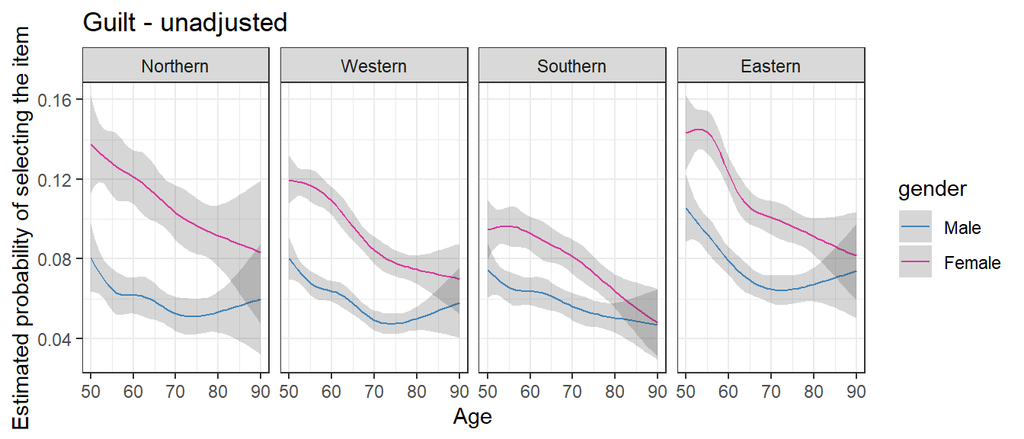

```r
i <- i+1

share.data.first.interview$y <- share.data.first.interview$euro4

my.mod2 <- glm(y ~ age1 + age2 + age3 + age4 + gender + region +
                      age1:region + age2:region + age3:region + age4:region +
                       age1:gender + age2:gender + age3:gender + age4:gender +
                       gender:region ,
                        data=share.data.first.interview, family="binomial",  x=TRUE, y=TRUE)



my.mod1 <- glm(y ~ rcspline.eval(age_int_stand, knots=Knots, inclx = TRUE)  + gender + region +
                      rcspline.eval(age_int_stand, knots=Knots, inclx = TRUE):region +
                       rcspline.eval(age_int_stand, knots=Knots, inclx = TRUE):gender +
                       gender:region ,
                        data=share.data.first.interview, family="binomial",  x=TRUE, y=TRUE)



my.pred <- predict(my.mod2, newdata=data.grid.region, se.fit = TRUE, type="response")


my.pred.all <- cbind.data.frame(data.grid.region, my.pred)
my.pred.all$item <- eurod_items[i]

#saving the prediction for the items
pred.items.unadj.region <- rbind.data.frame(pred.items.unadj.region, my.pred.all)

ggplot(my.pred.all, aes(age1 + 50, fit, color=gender)) + geom_line() + facet_wrap(region~., ncol=4) + labs(x="Age", y="Estimated probability of selecting the item") + scale_color_manual(values=c("#4699dd","#ff3db7" )) + ggtitle(paste(eurod_items[i], "- unadjusted")) + theme_bw()  +
   geom_ribbon(aes(ymin = fit - 1.96*se.fit, ymax = fit + 1.96*se.fit), alpha = 0.2, linetype=0)
```

```r
ggsave(paste0("eurod", i, "_region_Unadj.png"), device="png", path = "figures" , height = 4, width=10)

anova(my.mod1, test="Chi")
```

```
## Analysis of Deviance Table
##
## Model: binomial, link: logit
##
## Response: y
##
## Terms added sequentially (first to last)
##
##
##                                                                  Df Deviance
## NULL
## rcspline.eval(age_int_stand, knots = Knots, inclx = TRUE)         4      217
## gender                                                            1      489
## region                                                            3      111
## rcspline.eval(age_int_stand, knots = Knots, inclx = TRUE):region 12       13
## rcspline.eval(age_int_stand, knots = Knots, inclx = TRUE):gender  4        7
## gender:region                                                     3       18
##                                                                  Resid. Df
## NULL                                                                103933
## rcspline.eval(age_int_stand, knots = Knots, inclx = TRUE)           103929
## gender                                                              103928
## region                                                              103925
## rcspline.eval(age_int_stand, knots = Knots, inclx = TRUE):region    103913
## rcspline.eval(age_int_stand, knots = Knots, inclx = TRUE):gender    103909
## gender:region                                                       103906
##                                                                  Resid. Dev
## NULL                                                                  60871
## rcspline.eval(age_int_stand, knots = Knots, inclx = TRUE)             60654
## gender                                                                60165
## region                                                                60054
## rcspline.eval(age_int_stand, knots = Knots, inclx = TRUE):region      60042
## rcspline.eval(age_int_stand, knots = Knots, inclx = TRUE):gender      60034
## gender:region                                                         60017
##                                                                  Pr(>Chi)
## NULL
## rcspline.eval(age_int_stand, knots = Knots, inclx = TRUE)         < 2e-16 ***
## gender                                                            < 2e-16 ***
## region                                                            < 2e-16 ***
## rcspline.eval(age_int_stand, knots = Knots, inclx = TRUE):region  0.39169
## rcspline.eval(age_int_stand, knots = Knots, inclx = TRUE):gender  0.12219
## gender:region                                                     0.00051 ***
## ---
## Signif. codes:  0 '***' 0.001 '**' 0.01 '*' 0.05 '.' 0.1 ' ' 1
```

#### 2.2.4.2 Adjusted model with rcs for age

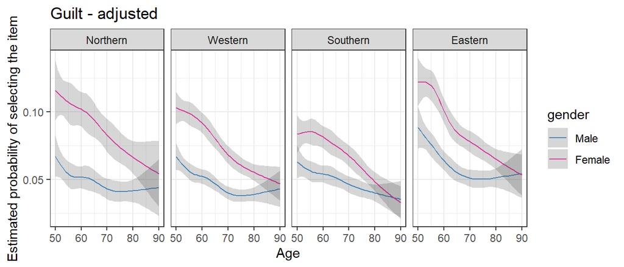

```r
my.mod1 <- glm(y ~ rcs(age_int) + gender + region +
                       rcs(age_int):region + rcs(age_int):gender + gender:region +
                       bmi_imp +  education_imp + cusmoke_imp + dis_chronic_pres +
                        pa_vig + living_arrangement,
                       data=share.data.first.interview, family="binomial",  x=TRUE, y=TRUE)


my.mod2 <- glm(y ~ age1 + age2 + age3 + age4 + gender + region +
                      age1:region + age2:region + age3:region + age4:region +
                       age1:gender + age2:gender + age3:gender + age4:gender +
                       gender:region +
                 bmi_imp + education_imp + cusmoke_imp + dis_chronic_pres +
                        pa_vig + living_arrangement,
                        data=share.data.first.interview, family="binomial",  x=TRUE, y=TRUE)

my.pred <- predict(my.mod2, newdata=data.grid.adj.region, se.fit = TRUE, type="response")


my.pred.all <- cbind.data.frame(data.grid.adj.region, my.pred)
my.pred.all$item <- eurod_items[i]

#saving the prediction for the items
pred.items.adj.region <- rbind.data.frame(pred.items.adj.region, my.pred.all)


ggplot(my.pred.all, aes(age1 + 50, fit, color=gender)) + geom_line() + facet_wrap(region~., ncol=4) + labs(x="Age", y="Estimated probability of selecting the item") + scale_color_manual(values=c("#4699dd","#ff3db7" )) + ggtitle(paste(eurod_items[i], "- adjusted")) +  theme_bw()  +
   geom_ribbon(aes(ymin = fit - 1.96*se.fit, ymax = fit + 1.96*se.fit), alpha = 0.2, linetype=0)
```

```r
ggsave(paste0("eurod", i, "_region_Adj.png"), device="png", path = "figures" , height = 4, width=10)

anova(my.mod1, test="Chi")
```

```
## Analysis of Deviance Table
##
## Model: binomial, link: logit
##
## Response: y
##
## Terms added sequentially (first to last)
##
##
##                     Df Deviance Resid. Df Resid. Dev Pr(>Chi)
## NULL                               103933      60871
## rcs(age_int)         4      217    103929      60654  < 2e-16 ***
## gender               1      489    103928      60165  < 2e-16 ***
## region               3      111    103925      60054  < 2e-16 ***
## bmi_imp              1        0    103924      60054   0.9294
## education_imp        3        7    103921      60048   0.0831 .
## cusmoke_imp          1      141    103920      59906  < 2e-16 ***
## dis_chronic_pres     2      157    103918      59749  < 2e-16 ***
## pa_vig               3       42    103915      59706  3.2e-09 ***
## living_arrangement   1       85    103914      59622  < 2e-16 ***
## rcs(age_int):region 12       14    103902      59608   0.3323
## rcs(age_int):gender  4       13    103898      59595   0.0119 *
## gender:region        3       15    103895      59580   0.0016 **
## ---
## Signif. codes:  0 '***' 0.001 '**' 0.01 '*' 0.05 '.' 0.1 ' ' 1
```

```r
OR3[[i]] <- get.OR3(my.mod1, names.var = c(1:9, "BMI", "Education : Medium","Education : High", "Education : Other","Current smoking : Yes", "Chronic diseases : 1" , "Chronic diseases: 2+", "Vigorous PA : Once a week", "Vigorous PA : 1−3 times a month", "Vigorous PA : Hardly ever, or never", "Living alone : Yes", 21:39))[10:20,]

OR2[[i]] <- get.OR2(my.mod1, names.var = c(1:9, "BMI", "Education : Medium","Education : High", "Education : Other","Current smoking : Yes", "Chronic diseases : 1" , "Chronic diseases: 2+", "Vigorous PA : Once a week", "Vigorous PA : 1−3 times a month", "Vigorous PA : Hardly ever, or never", "Living alone : Yes", 21:39))[10:20,]

kable(OR3[[i]], caption=paste(eurod_items_2names[i], "- OR for the risk factors"))
```

euro4 - Guilt - OR for the risk factors

|  | OR | 95% CI | P |
| --- | --- | --- | --- |
| BMI | 0.96 | 0.91-1.01 | 0.09 |
| Education : Medium | 1.02 | 0.96-1.07 | 0.55 |
| Education : High | 1.12 | 1.05-1.19 | <0.01 |
| Education : Other | 0.81 | 0.55-1.17 | 0.26 |
| Current smoking : Yes | 1.34 | 1.27-1.41 | <0.01 |
| Chronic diseases : 1 | 1.18 | 1.12-1.24 | <0.01 |
| Chronic diseases: 2+ | 1.46 | 1.37-1.56 | <0.01 |
| Vigorous PA : Once a week | 0.95 | 0.88-1.02 | 0.13 |
| Vigorous PA : 1-3 times a month | 0.87 | 0.8-0.95 | <0.01 |
| Vigorous PA : Hardly ever, or never | 1.10 | 1.04-1.16 | <0.01 |
| Living alone : Yes | 1.27 | 1.21-1.34 | <0.01 |

### 2.2.5 Item 5 - Sleep

#### 2.2.5.1 Unadjusted model with rcs for age

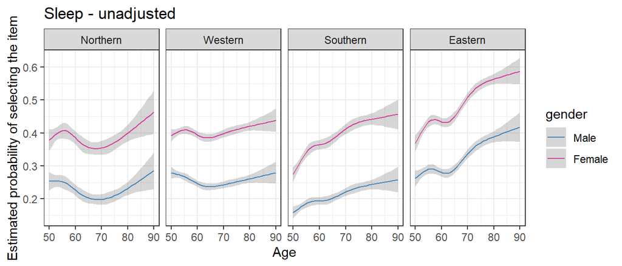

```r
i <- i+1

share.data.first.interview$y <- share.data.first.interview$euro5

my.mod2 <- glm(y ~ age1 + age2 + age3 + age4 + gender + region +
                      age1:region + age2:region + age3:region + age4:region +
                       age1:gender + age2:gender + age3:gender + age4:gender +
                       gender:region ,
                        data=share.data.first.interview, family="binomial",  x=TRUE, y=TRUE)



my.mod1 <- glm(y ~ rcspline.eval(age_int_stand, knots=Knots, inclx = TRUE)  + gender + region +
                      rcspline.eval(age_int_stand, knots=Knots, inclx = TRUE):region +
                       rcspline.eval(age_int_stand, knots=Knots, inclx = TRUE):gender +
                       gender:region ,
                        data=share.data.first.interview, family="binomial",  x=TRUE, y=TRUE)



my.pred <- predict(my.mod2, newdata=data.grid.region, se.fit = TRUE, type="response")


my.pred.all <- cbind.data.frame(data.grid.region, my.pred)
my.pred.all$item <- eurod_items[i]

#saving the prediction for the items
pred.items.unadj.region <- rbind.data.frame(pred.items.unadj.region, my.pred.all)

ggplot(my.pred.all, aes(age1 + 50, fit, color=gender)) + geom_line() + facet_wrap(region~., ncol=4) + labs(x="Age", y="Estimated probability of selecting the item") + scale_color_manual(values=c("#4699dd","#ff3db7" )) + ggtitle(paste(eurod_items[i], "- unadjusted")) + theme_bw()  +
   geom_ribbon(aes(ymin = fit - 1.96*se.fit, ymax = fit + 1.96*se.fit), alpha = 0.2, linetype=0)
```

```r
ggsave(paste0("eurod", i, "_region_Unadj.png"), device="png", path = "figures" , height = 4, width=10)

anova(my.mod1, test="Chi")
```

```
## Analysis of Deviance Table
##
## Model: binomial, link: logit
##
## Response: y
##
## Terms added sequentially (first to last)
##
##
##                                                                  Df Deviance
## NULL
## rcspline.eval(age_int_stand, knots = Knots, inclx = TRUE)         4      245
## gender                                                            1     2881
## region                                                            3      638
## rcspline.eval(age_int_stand, knots = Knots, inclx = TRUE):region 12      267
## rcspline.eval(age_int_stand, knots = Knots, inclx = TRUE):gender  4       21
## gender:region                                                     3       30
##                                                                  Resid. Df
## NULL                                                                104053
## rcspline.eval(age_int_stand, knots = Knots, inclx = TRUE)           104049
## gender                                                              104048
## region                                                              104045
## rcspline.eval(age_int_stand, knots = Knots, inclx = TRUE):region    104033
## rcspline.eval(age_int_stand, knots = Knots, inclx = TRUE):gender    104029
## gender:region                                                       104026
##                                                                  Resid. Dev
## NULL                                                                 133348
## rcspline.eval(age_int_stand, knots = Knots, inclx = TRUE)            133104
## gender                                                               130222
## region                                                               129584
## rcspline.eval(age_int_stand, knots = Knots, inclx = TRUE):region     129317
## rcspline.eval(age_int_stand, knots = Knots, inclx = TRUE):gender     129296
## gender:region                                                        129266
##                                                                  Pr(>Chi)
## NULL
## rcspline.eval(age_int_stand, knots = Knots, inclx = TRUE)         < 2e-16 ***
## gender                                                            < 2e-16 ***
## region                                                            < 2e-16 ***
## rcspline.eval(age_int_stand, knots = Knots, inclx = TRUE):region  < 2e-16 ***
## rcspline.eval(age_int_stand, knots = Knots, inclx = TRUE):gender  0.00029 ***
## gender:region                                                     1.6e-06 ***
## ---
## Signif. codes:  0 '***' 0.001 '**' 0.01 '*' 0.05 '.' 0.1 ' ' 1
```

#### 2.2.5.2 Adjusted model with rcs for age

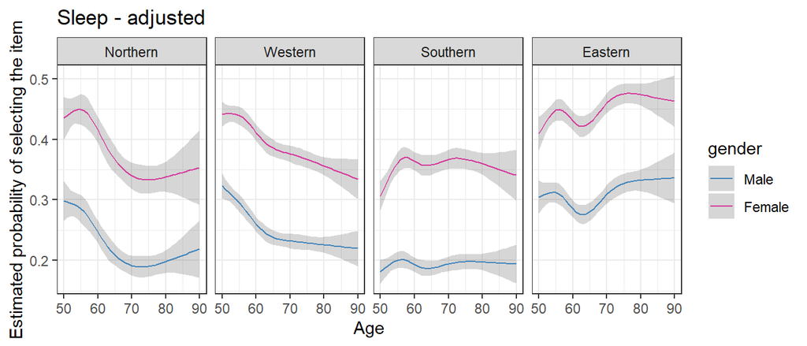

```r
my.mod1 <- glm(y ~ rcs(age_int) + gender + region +
                       rcs(age_int):region + rcs(age_int):gender + gender:region +
                       bmi_imp +  education_imp + cusmoke_imp + dis_chronic_pres +
                        pa_vig + living_arrangement,
                       data=share.data.first.interview, family="binomial",  x=TRUE, y=TRUE)


my.mod2 <- glm(y ~ age1 + age2 + age3 + age4 + gender + region +
                      age1:region + age2:region + age3:region + age4:region +
                       age1:gender + age2:gender + age3:gender + age4:gender +
                       gender:region +
                 bmi_imp + education_imp + cusmoke_imp + dis_chronic_pres +
                        pa_vig + living_arrangement,
                        data=share.data.first.interview, family="binomial",  x=TRUE, y=TRUE)

my.pred <- predict(my.mod2, newdata=data.grid.adj.region, se.fit = TRUE, type="response")


my.pred.all <- cbind.data.frame(data.grid.adj.region, my.pred)
my.pred.all$item <- eurod_items[i]

#saving the prediction for the items
pred.items.adj.region <- rbind.data.frame(pred.items.adj.region, my.pred.all)


ggplot(my.pred.all, aes(age1 + 50, fit, color=gender)) + geom_line() + facet_wrap(region~., ncol=4) + labs(x="Age", y="Estimated probability of selecting the item") + scale_color_manual(values=c("#4699dd","#ff3db7" )) + ggtitle(paste(eurod_items[i], "- adjusted")) +  theme_bw()  +
   geom_ribbon(aes(ymin = fit - 1.96*se.fit, ymax = fit + 1.96*se.fit), alpha = 0.2, linetype=0)
```

```r
ggsave(paste0("eurod", i, "_region_Adj.png"), device="png", path = "figures" , height = 4, width=10)

anova(my.mod1, test="Chi")
```

```
## Analysis of Deviance Table
##
## Model: binomial, link: logit
##
## Response: y
##
## Terms added sequentially (first to last)
##
##
##                     Df Deviance Resid. Df Resid. Dev Pr(>Chi)
## NULL                               104053     133348
## rcs(age_int)         4      245    104049     133104  < 2e-16 ***
## gender               1     2881    104048     130222  < 2e-16 ***
## region               3      638    104045     129584  < 2e-16 ***
## bmi_imp              1      150    104044     129434  < 2e-16 ***
## education_imp        3      259    104041     129176  < 2e-16 ***
## cusmoke_imp          1        1    104040     129175   0.2613
## dis_chronic_pres     2     1656    104038     127519  < 2e-16 ***
## pa_vig               3      478    104035     127041  < 2e-16 ***
## living_arrangement   1      101    104034     126940  < 2e-16 ***
## rcs(age_int):region 12      225    104022     126716  < 2e-16 ***
## rcs(age_int):gender  4       15    104018     126700   0.0045 **
## gender:region        3       38    104015     126663  3.1e-08 ***
## ---
## Signif. codes:  0 '***' 0.001 '**' 0.01 '*' 0.05 '.' 0.1 ' ' 1
```

```r
OR3[[i]] <- get.OR3(my.mod1, names.var = c(1:9, "BMI", "Education : Medium","Education : High", "Education : Other","Current smoking : Yes", "Chronic diseases : 1" , "Chronic diseases: 2+", "Vigorous PA : Once a week", "Vigorous PA : 1−3 times a month", "Vigorous PA : Hardly ever, or never", "Living alone : Yes", 21:39))[10:20,]

OR2[[i]] <- get.OR2(my.mod1, names.var = c(1:9, "BMI", "Education : Medium","Education : High", "Education : Other","Current smoking : Yes", "Chronic diseases : 1" , "Chronic diseases: 2+", "Vigorous PA : Once a week", "Vigorous PA : 1−3 times a month", "Vigorous PA : Hardly ever, or never", "Living alone : Yes", 21:39))[10:20,]

kable(OR3[[i]], caption=paste(eurod_items_2names[i], "- OR for the risk factors"))
```

euro5 - Sleep - OR for the risk factors

|  | OR | 95% CI | P |
| --- | --- | --- | --- |
| BMI | 0.99 | 0.96-1.02 | 0.67 |
| Education : Medium | 0.87 | 0.84-0.89 | <0.01 |
| Education : High | 0.80 | 0.77-0.83 | <0.01 |
| Education : Other | 1.25 | 1.03-1.52 | 0.03 |
| Current smoking : Yes | 1.00 | 0.96-1.03 | 0.87 |
| Chronic diseases : 1 | 1.40 | 1.36-1.44 | <0.01 |
| Chronic diseases: 2+ | 2.06 | 1.98-2.14 | <0.01 |
| Vigorous PA : Once a week | 1.01 | 0.97-1.06 | 0.52 |
| Vigorous PA : 1-3 times a month | 0.99 | 0.94-1.04 | 0.72 |
| Vigorous PA : Hardly ever, or never | 1.37 | 1.33-1.42 | <0.01 |
| Living alone : Yes | 1.16 | 1.13-1.2 | <0.01 |

### 2.2.6 Item 6 - Interest

#### 2.2.6.1 Unadjusted model with rcs for age

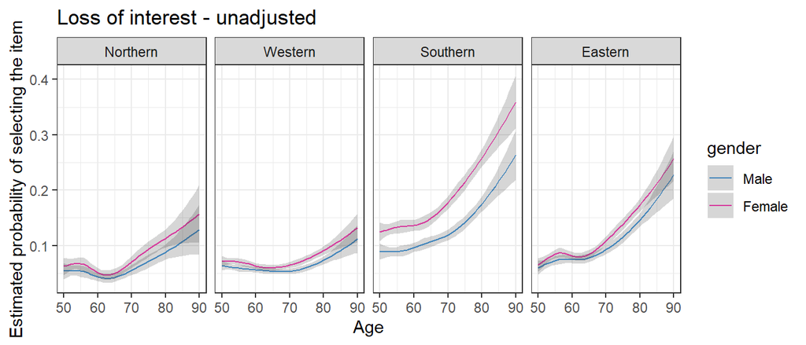

```r
i <- i+1

share.data.first.interview$y <- share.data.first.interview$euro6

my.mod2 <- glm(y ~ age1 + age2 + age3 + age4 + gender + region +
                      age1:region + age2:region + age3:region + age4:region +
                       age1:gender + age2:gender + age3:gender + age4:gender +
                       gender:region ,
                        data=share.data.first.interview, family="binomial",  x=TRUE, y=TRUE)



my.mod1 <- glm(y ~ rcspline.eval(age_int_stand, knots=Knots, inclx = TRUE)  + gender + region +
                      rcspline.eval(age_int_stand, knots=Knots, inclx = TRUE):region +
                       rcspline.eval(age_int_stand, knots=Knots, inclx = TRUE):gender +
                       gender:region ,
                        data=share.data.first.interview, family="binomial",  x=TRUE, y=TRUE)



my.pred <- predict(my.mod2, newdata=data.grid.region, se.fit = TRUE, type="response")


my.pred.all <- cbind.data.frame(data.grid.region, my.pred)
my.pred.all$item <- eurod_items[i]

#saving the prediction for the items
pred.items.unadj.region <- rbind.data.frame(pred.items.unadj.region, my.pred.all)

ggplot(my.pred.all, aes(age1 + 50, fit, color=gender)) + geom_line() + facet_wrap(region~., ncol=4) + labs(x="Age", y="Estimated probability of selecting the item") + scale_color_manual(values=c("#4699dd","#ff3db7" )) + ggtitle(paste(eurod_items[i], "- unadjusted")) + theme_bw()  +
   geom_ribbon(aes(ymin = fit - 1.96*se.fit, ymax = fit + 1.96*se.fit), alpha = 0.2, linetype=0)
```

```r
ggsave(paste0("eurod", i, "_region_Unadj.png"), device="png", path = "figures" , height = 4, width=10)

anova(my.mod1, test="Chi")
```

```
## Analysis of Deviance Table
##
## Model: binomial, link: logit
##
## Response: y
##
## Terms added sequentially (first to last)
##
##
##                                                                  Df Deviance
## NULL
## rcspline.eval(age_int_stand, knots = Knots, inclx = TRUE)         4      622
## gender                                                            1      134
## region                                                            3     1067
## rcspline.eval(age_int_stand, knots = Knots, inclx = TRUE):region 12      107
## rcspline.eval(age_int_stand, knots = Knots, inclx = TRUE):gender  4        5
## gender:region                                                     3       33
##                                                                  Resid. Df
## NULL                                                                103998
## rcspline.eval(age_int_stand, knots = Knots, inclx = TRUE)           103994
## gender                                                              103993
## region                                                              103990
## rcspline.eval(age_int_stand, knots = Knots, inclx = TRUE):region    103978
## rcspline.eval(age_int_stand, knots = Knots, inclx = TRUE):gender    103974
## gender:region                                                       103971
##                                                                  Resid. Dev
## NULL                                                                  62868
## rcspline.eval(age_int_stand, knots = Knots, inclx = TRUE)             62246
## gender                                                                62112
## region                                                                61045
## rcspline.eval(age_int_stand, knots = Knots, inclx = TRUE):region      60938
## rcspline.eval(age_int_stand, knots = Knots, inclx = TRUE):gender      60933
## gender:region                                                         60901
##                                                                  Pr(>Chi)
## NULL
## rcspline.eval(age_int_stand, knots = Knots, inclx = TRUE)         < 2e-16 ***
## gender                                                            < 2e-16 ***
## region                                                            < 2e-16 ***
## rcspline.eval(age_int_stand, knots = Knots, inclx = TRUE):region  < 2e-16 ***
## rcspline.eval(age_int_stand, knots = Knots, inclx = TRUE):gender     0.33
## gender:region                                                     3.5e-07 ***
## ---
## Signif. codes:  0 '***' 0.001 '**' 0.01 '*' 0.05 '.' 0.1 ' ' 1
```

#### 2.2.6.2 Adjusted model with rcs for age

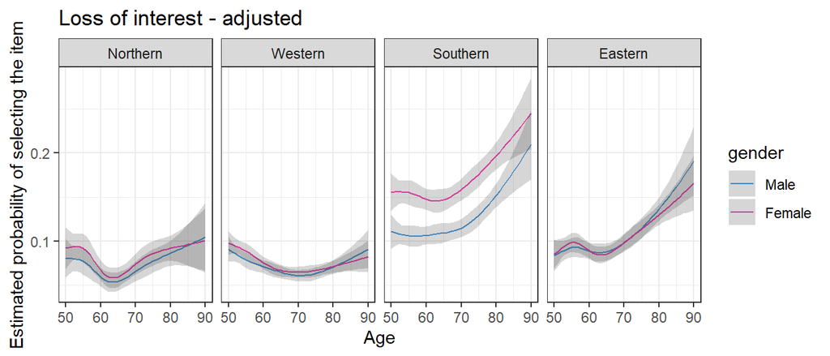

```r
my.mod1 <- glm(y ~ rcs(age_int) + gender + region +
                       rcs(age_int):region + rcs(age_int):gender + gender:region +
                       bmi_imp +  education_imp + cusmoke_imp + dis_chronic_pres +
                        pa_vig + living_arrangement,
                       data=share.data.first.interview, family="binomial",  x=TRUE, y=TRUE)


my.mod2 <- glm(y ~ age1 + age2 + age3 + age4 + gender + region +
                      age1:region + age2:region + age3:region + age4:region +
                       age1:gender + age2:gender + age3:gender + age4:gender +
                       gender:region +
                 bmi_imp + education_imp + cusmoke_imp + dis_chronic_pres +
                        pa_vig + living_arrangement,
                        data=share.data.first.interview, family="binomial",  x=TRUE, y=TRUE)

my.pred <- predict(my.mod2, newdata=data.grid.adj.region, se.fit = TRUE, type="response")


my.pred.all <- cbind.data.frame(data.grid.adj.region, my.pred)
my.pred.all$item <- eurod_items[i]

#saving the prediction for the items
pred.items.adj.region <- rbind.data.frame(pred.items.adj.region, my.pred.all)


ggplot(my.pred.all, aes(age1 + 50, fit, color=gender)) + geom_line() + facet_wrap(region~., ncol=4) + labs(x="Age", y="Estimated probability of selecting the item") + scale_color_manual(values=c("#4699dd","#ff3db7" )) + ggtitle(paste(eurod_items[i], "- adjusted")) +  theme_bw()  +
   geom_ribbon(aes(ymin = fit - 1.96*se.fit, ymax = fit + 1.96*se.fit), alpha = 0.2, linetype=0)
```

```r
ggsave(paste0("eurod", i, "_region_Adj.png"), device="png", path = "figures" , height = 4, width=10)

anova(my.mod1, test="Chi")
```

```
## Analysis of Deviance Table
##
## Model: binomial, link: logit
##
## Response: y
##
## Terms added sequentially (first to last)
##
##
##                     Df Deviance Resid. Df Resid. Dev Pr(>Chi)
## NULL                               103998      62868
## rcs(age_int)         4      622    103994      62246  < 2e-16 ***
## gender               1      134    103993      62112  < 2e-16 ***
## region               3     1067    103990      61045  < 2e-16 ***
## bmi_imp              1       33    103989      61012  7.8e-09 ***
## education_imp        3      325    103986      60687  < 2e-16 ***
## cusmoke_imp          1      119    103985      60568  < 2e-16 ***
## dis_chronic_pres     2      455    103983      60113  < 2e-16 ***
## pa_vig               3      576    103980      59537  < 2e-16 ***
## living_arrangement   1      197    103979      59340  < 2e-16 ***
## rcs(age_int):region 12       98    103967      59242  1.4e-15 ***
## rcs(age_int):gender  4        3    103963      59239     0.48
## gender:region        3       48    103960      59191  2.2e-10 ***
## ---
## Signif. codes:  0 '***' 0.001 '**' 0.01 '*' 0.05 '.' 0.1 ' ' 1
```

```r
OR3[[i]] <- get.OR3(my.mod1, names.var = c(1:9, "BMI", "Education : Medium","Education : High", "Education : Other","Current smoking : Yes", "Chronic diseases : 1" , "Chronic diseases: 2+", "Vigorous PA : Once a week", "Vigorous PA : 1−3 times a month", "Vigorous PA : Hardly ever, or never", "Living alone : Yes", 21:39))[10:20,]

OR2[[i]] <- get.OR2(my.mod1, names.var = c(1:9, "BMI", "Education : Medium","Education : High", "Education : Other","Current smoking : Yes", "Chronic diseases : 1" , "Chronic diseases: 2+", "Vigorous PA : Once a week", "Vigorous PA : 1−3 times a month", "Vigorous PA : Hardly ever, or never", "Living alone : Yes", 21:39))[10:20,]

kable(OR3[[i]], caption=paste(eurod_items_2names[i], "- OR for the risk factors"))
```

euro6 - Loss of interest - OR for the risk factors

|  | OR | 95% CI | P |
| --- | --- | --- | --- |
| BMI | 0.97 | 0.93-1.02 | 0.28 |
| Education : Medium | 0.75 | 0.71-0.79 | <0.01 |
| Education : High | 0.63 | 0.59-0.68 | <0.01 |
| Education : Other | 0.93 | 0.68-1.28 | 0.67 |
| Current smoking : Yes | 1.30 | 1.23-1.37 | <0.01 |
| Chronic diseases : 1 | 1.31 | 1.25-1.38 | <0.01 |
| Chronic diseases: 2+ | 1.72 | 1.62-1.83 | <0.01 |
| Vigorous PA : Once a week | 1.08 | 1-1.17 | 0.07 |
| Vigorous PA : 1-3 times a month | 1.31 | 1.2-1.42 | <0.01 |
| Vigorous PA : Hardly ever, or never | 1.85 | 1.75-1.96 | <0.01 |
| Living alone : Yes | 1.42 | 1.35-1.49 | <0.01 |

### 2.2.7 Item 7 - Irritability

#### 2.2.7.1 Unadjusted model with rcs for age

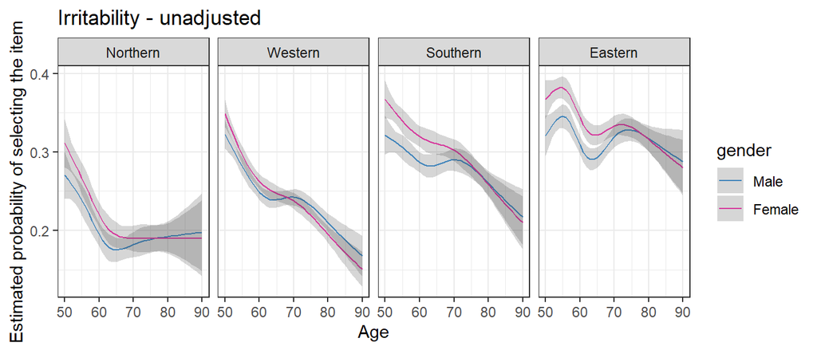

```r
i <- i+1

share.data.first.interview$y <- share.data.first.interview$euro7

my.mod2 <- glm(y ~ age1 + age2 + age3 + age4 + gender + region +
                      age1:region + age2:region + age3:region + age4:region +
                       age1:gender + age2:gender + age3:gender + age4:gender +
                       gender:region ,
                        data=share.data.first.interview, family="binomial",  x=TRUE, y=TRUE)



my.mod1 <- glm(y ~ rcspline.eval(age_int_stand, knots=Knots, inclx = TRUE)  + gender + region +
                      rcspline.eval(age_int_stand, knots=Knots, inclx = TRUE):region +
                       rcspline.eval(age_int_stand, knots=Knots, inclx = TRUE):gender +
                       gender:region ,
                        data=share.data.first.interview, family="binomial",  x=TRUE, y=TRUE)



my.pred <- predict(my.mod2, newdata=data.grid.region, se.fit = TRUE, type="response")


my.pred.all <- cbind.data.frame(data.grid.region, my.pred)
my.pred.all$item <- eurod_items[i]

#saving the prediction for the items
pred.items.unadj.region <- rbind.data.frame(pred.items.unadj.region, my.pred.all)

ggplot(my.pred.all, aes(age1 + 50, fit, color=gender)) + geom_line() + facet_wrap(region~., ncol=4) + labs(x="Age", y="Estimated probability of selecting the item") + scale_color_manual(values=c("#4699dd","#ff3db7" )) + ggtitle(paste(eurod_items[i], "- unadjusted")) + theme_bw()  +
   geom_ribbon(aes(ymin = fit - 1.96*se.fit, ymax = fit + 1.96*se.fit), alpha = 0.2, linetype=0)
```

```r
ggsave(paste0("eurod", i, "_region_Unadj.png"), device="png", path = "figures" , height = 4, width=10)

anova(my.mod1, test="Chi")
```

```
## Analysis of Deviance Table
##
## Model: binomial, link: logit
##
## Response: y
##
## Terms added sequentially (first to last)
##
##
##                                                                  Df Deviance
## NULL
## rcspline.eval(age_int_stand, knots = Knots, inclx = TRUE)         4      409
## gender                                                            1       44
## region                                                            3      775
## rcspline.eval(age_int_stand, knots = Knots, inclx = TRUE):region 12       89
## rcspline.eval(age_int_stand, knots = Knots, inclx = TRUE):gender  4       21
## gender:region                                                     3        9
##                                                                  Resid. Df
## NULL                                                                103986
## rcspline.eval(age_int_stand, knots = Knots, inclx = TRUE)           103982
## gender                                                              103981
## region                                                              103978
## rcspline.eval(age_int_stand, knots = Knots, inclx = TRUE):region    103966
## rcspline.eval(age_int_stand, knots = Knots, inclx = TRUE):gender    103962
## gender:region                                                       103959
##                                                                  Resid. Dev
## NULL                                                                 124166
## rcspline.eval(age_int_stand, knots = Knots, inclx = TRUE)            123757
## gender                                                               123713
## region                                                               122938
## rcspline.eval(age_int_stand, knots = Knots, inclx = TRUE):region     122849
## rcspline.eval(age_int_stand, knots = Knots, inclx = TRUE):gender     122828
## gender:region                                                        122819
##                                                                  Pr(>Chi)
## NULL
## rcspline.eval(age_int_stand, knots = Knots, inclx = TRUE)         < 2e-16 ***
## gender                                                            3.5e-11 ***
## region                                                            < 2e-16 ***
## rcspline.eval(age_int_stand, knots = Knots, inclx = TRUE):region  7.2e-14 ***
## rcspline.eval(age_int_stand, knots = Knots, inclx = TRUE):gender  0.00032 ***
## gender:region                                                     0.03149 *
## ---
## Signif. codes:  0 '***' 0.001 '**' 0.01 '*' 0.05 '.' 0.1 ' ' 1
```

#### 2.2.7.2 Adjusted model with rcs for age

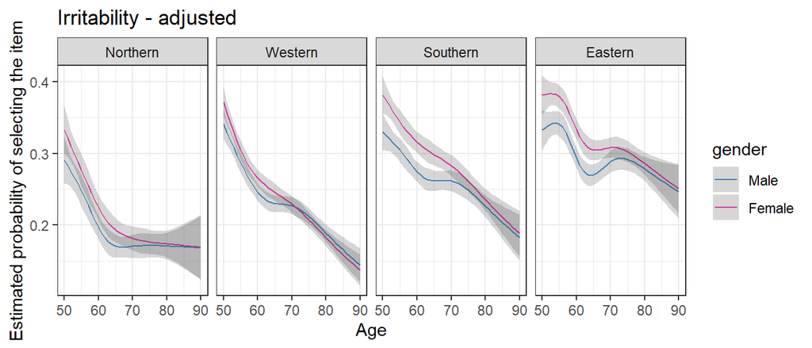

```r
my.mod1 <- glm(y ~ rcs(age_int) + gender + region +
                       rcs(age_int):region + rcs(age_int):gender + gender:region +
                       bmi_imp +  education_imp + cusmoke_imp + dis_chronic_pres +
                        pa_vig + living_arrangement,
                       data=share.data.first.interview, family="binomial",  x=TRUE, y=TRUE)


my.mod2 <- glm(y ~ age1 + age2 + age3 + age4 + gender + region +
                      age1:region + age2:region + age3:region + age4:region +
                       age1:gender + age2:gender + age3:gender + age4:gender +
                       gender:region +
                 bmi_imp + education_imp + cusmoke_imp + dis_chronic_pres +
                        pa_vig + living_arrangement,
                        data=share.data.first.interview, family="binomial",  x=TRUE, y=TRUE)

my.pred <- predict(my.mod2, newdata=data.grid.adj.region, se.fit = TRUE, type="response")


my.pred.all <- cbind.data.frame(data.grid.adj.region, my.pred)
my.pred.all$item <- eurod_items[i]

#saving the prediction for the items
pred.items.adj.region <- rbind.data.frame(pred.items.adj.region, my.pred.all)


ggplot(my.pred.all, aes(age1 + 50, fit, color=gender)) + geom_line() + facet_wrap(region~., ncol=4) + labs(x="Age", y="Estimated probability of selecting the item") + scale_color_manual(values=c("#4699dd","#ff3db7" )) + ggtitle(paste(eurod_items[i], "- adjusted")) +  theme_bw()  +
   geom_ribbon(aes(ymin = fit - 1.96*se.fit, ymax = fit + 1.96*se.fit), alpha = 0.2, linetype=0)
```

```r
ggsave(paste0("eurod", i, "_region_Adj.png"), device="png", path = "figures" , height = 4, width=10)

anova(my.mod1, test="Chi")
```

```
## Analysis of Deviance Table
##
## Model: binomial, link: logit
##
## Response: y
##
## Terms added sequentially (first to last)
##
##
##                     Df Deviance Resid. Df Resid. Dev Pr(>Chi)
## NULL                               103986     124166
## rcs(age_int)         4      409    103982     123757  < 2e-16 ***
## gender               1       44    103981     123713  3.5e-11 ***
## region               3      775    103978     122938  < 2e-16 ***
## bmi_imp              1       82    103977     122856  < 2e-16 ***
## education_imp        3       55    103974     122801  7.8e-12 ***
## cusmoke_imp          1      101    103973     122700  < 2e-16 ***
## dis_chronic_pres     2      808    103971     121892  < 2e-16 ***
## pa_vig               3      155    103968     121737  < 2e-16 ***
## living_arrangement   1      108    103967     121629  < 2e-16 ***
## rcs(age_int):region 12       81    103955     121548  2.7e-12 ***
## rcs(age_int):gender  4       14    103951     121533    0.006 **
## gender:region        3        9    103948     121525    0.034 *
## ---
## Signif. codes:  0 '***' 0.001 '**' 0.01 '*' 0.05 '.' 0.1 ' ' 1
```

```r
OR3[[i]] <- get.OR3(my.mod1, names.var = c(1:9, "BMI", "Education : Medium","Education : High", "Education : Other","Current smoking : Yes", "Chronic diseases : 1" , "Chronic diseases: 2+", "Vigorous PA : Once a week", "Vigorous PA : 1−3 times a month", "Vigorous PA : Hardly ever, or never", "Living alone : Yes", 21:39))[10:20,]

OR2[[i]] <- get.OR2(my.mod1, names.var = c(1:9, "BMI", "Education : Medium","Education : High", "Education : Other","Current smoking : Yes", "Chronic diseases : 1" , "Chronic diseases: 2+", "Vigorous PA : Once a week", "Vigorous PA : 1−3 times a month", "Vigorous PA : Hardly ever, or never", "Living alone : Yes", 21:39))[10:20,]

kable(OR3[[i]], caption=paste(eurod_items_2names[i], "- OR for the risk factors"))
```

euro7 - Irritability - OR for the risk factors

|  | OR | 95% CI | P |
| --- | --- | --- | --- |
| BMI | 1.03 | 1-1.06 | 0.05 |
| Education : Medium | 0.96 | 0.93-0.99 | <0.01 |
| Education : High | 0.91 | 0.87-0.94 | <0.01 |
| Education : Other | 0.94 | 0.76-1.16 | 0.55 |
| Current smoking : Yes | 1.22 | 1.17-1.26 | <0.01 |
| Chronic diseases : 1 | 1.25 | 1.21-1.29 | <0.01 |
| Chronic diseases: 2+ | 1.71 | 1.64-1.78 | <0.01 |
| Vigorous PA : Once a week | 0.92 | 0.88-0.96 | <0.01 |
| Vigorous PA : 1-3 times a month | 0.97 | 0.92-1.02 | 0.18 |
| Vigorous PA : Hardly ever, or never | 1.17 | 1.13-1.21 | <0.01 |
| Living alone : Yes | 0.85 | 0.82-0.88 | <0.01 |

### 2.2.8 Item 8 - Appetite

#### 2.2.8.1 Unadjusted model with rcs for age

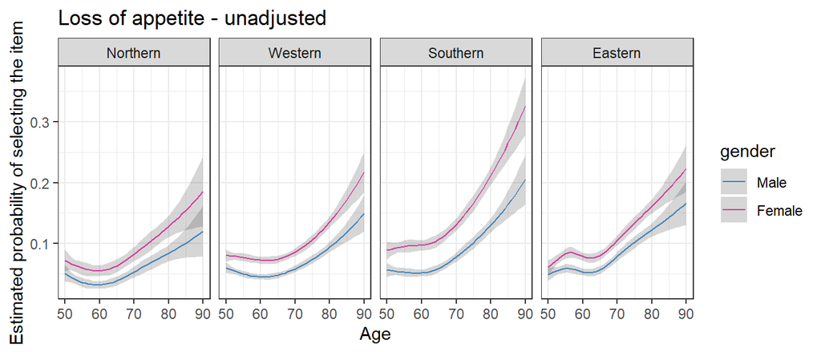

```r
i <- i+1

share.data.first.interview$y <- share.data.first.interview$euro8

my.mod2 <- glm(y ~ age1 + age2 + age3 + age4 + gender + region +
                      age1:region + age2:region + age3:region + age4:region +
                       age1:gender + age2:gender + age3:gender + age4:gender +
                       gender:region ,
                        data=share.data.first.interview, family="binomial",  x=TRUE, y=TRUE)



my.mod1 <- glm(y ~ rcspline.eval(age_int_stand, knots=Knots, inclx = TRUE)  + gender + region +
                      rcspline.eval(age_int_stand, knots=Knots, inclx = TRUE):region +
                       rcspline.eval(age_int_stand, knots=Knots, inclx = TRUE):gender +
                       gender:region ,
                        data=share.data.first.interview, family="binomial",  x=TRUE, y=TRUE)



my.pred <- predict(my.mod2, newdata=data.grid.region, se.fit = TRUE, type="response")


my.pred.all <- cbind.data.frame(data.grid.region, my.pred)
my.pred.all$item <- eurod_items[i]

#saving the prediction for the items
pred.items.unadj.region <- rbind.data.frame(pred.items.unadj.region, my.pred.all)

ggplot(my.pred.all, aes(age1 + 50, fit, color=gender)) + geom_line() + facet_wrap(region~., ncol=4) + labs(x="Age", y="Estimated probability of selecting the item") + scale_color_manual(values=c("#4699dd","#ff3db7" )) + ggtitle(paste(eurod_items[i], "- unadjusted")) + theme_bw()  +
   geom_ribbon(aes(ymin = fit - 1.96*se.fit, ymax = fit + 1.96*se.fit), alpha = 0.2, linetype=0)
```

```r
ggsave(paste0("eurod", i, "_region_Unadj.png"), device="png", path = "figures" , height = 4, width=10)

anova(my.mod1, test="Chi")
```

```
## Analysis of Deviance Table
##
## Model: binomial, link: logit
##
## Response: y
##
## Terms added sequentially (first to last)
##
##
##                                                                  Df Deviance
## NULL
## rcspline.eval(age_int_stand, knots = Knots, inclx = TRUE)         4      888
## gender                                                            1      385
## region                                                            3      173
## rcspline.eval(age_int_stand, knots = Knots, inclx = TRUE):region 12       38
## rcspline.eval(age_int_stand, knots = Knots, inclx = TRUE):gender  4        4
## gender:region                                                     3       17
##                                                                  Resid. Df
## NULL                                                                104061
## rcspline.eval(age_int_stand, knots = Knots, inclx = TRUE)           104057
## gender                                                              104056
## region                                                              104053
## rcspline.eval(age_int_stand, knots = Knots, inclx = TRUE):region    104041
## rcspline.eval(age_int_stand, knots = Knots, inclx = TRUE):gender    104037
## gender:region                                                       104034
##                                                                  Resid. Dev
## NULL                                                                  58894
## rcspline.eval(age_int_stand, knots = Knots, inclx = TRUE)             58005
## gender                                                                57620
## region                                                                57448
## rcspline.eval(age_int_stand, knots = Knots, inclx = TRUE):region      57409
## rcspline.eval(age_int_stand, knots = Knots, inclx = TRUE):gender      57406
## gender:region                                                         57389
##                                                                  Pr(>Chi)
## NULL
## rcspline.eval(age_int_stand, knots = Knots, inclx = TRUE)         < 2e-16 ***
## gender                                                            < 2e-16 ***
## region                                                            < 2e-16 ***
## rcspline.eval(age_int_stand, knots = Knots, inclx = TRUE):region  0.00014 ***
## rcspline.eval(age_int_stand, knots = Knots, inclx = TRUE):gender  0.45684
## gender:region                                                     0.00063 ***
## ---
## Signif. codes:  0 '***' 0.001 '**' 0.01 '*' 0.05 '.' 0.1 ' ' 1
```

#### 2.2.8.2 Adjusted model with rcs for age

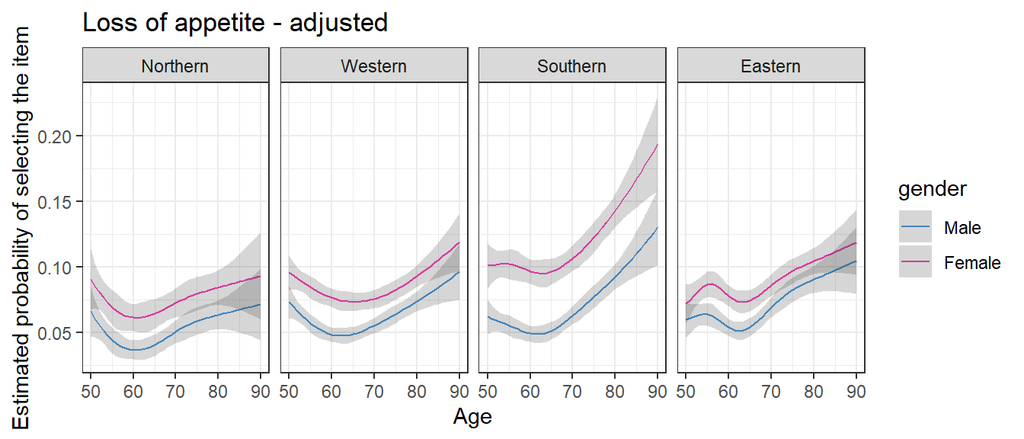

```r
my.mod1 <- glm(y ~ rcs(age_int) + gender + region +
                       rcs(age_int):region + rcs(age_int):gender + gender:region +
                       bmi_imp +  education_imp + cusmoke_imp + dis_chronic_pres +
                        pa_vig + living_arrangement,
                       data=share.data.first.interview, family="binomial",  x=TRUE, y=TRUE)


my.mod2 <- glm(y ~ age1 + age2 + age3 + age4 + gender + region +
                      age1:region + age2:region + age3:region + age4:region +
                       age1:gender + age2:gender + age3:gender + age4:gender +
                       gender:region +
                 bmi_imp + education_imp + cusmoke_imp + dis_chronic_pres +
                        pa_vig + living_arrangement,
                        data=share.data.first.interview, family="binomial",  x=TRUE, y=TRUE)

my.pred <- predict(my.mod2, newdata=data.grid.adj.region, se.fit = TRUE, type="response")


my.pred.all <- cbind.data.frame(data.grid.adj.region, my.pred)
my.pred.all$item <- eurod_items[i]

#saving the prediction for the items
pred.items.adj.region <- rbind.data.frame(pred.items.adj.region, my.pred.all)


ggplot(my.pred.all, aes(age1 + 50, fit, color=gender)) + geom_line() + facet_wrap(region~., ncol=4) + labs(x="Age", y="Estimated probability of selecting the item") + scale_color_manual(values=c("#4699dd","#ff3db7" )) + ggtitle(paste(eurod_items[i], "- adjusted")) +  theme_bw()  +
   geom_ribbon(aes(ymin = fit - 1.96*se.fit, ymax = fit + 1.96*se.fit), alpha = 0.2, linetype=0)
```

```r
ggsave(paste0("eurod", i, "_region_Adj.png"), device="png", path = "figures" , height = 4, width=10)

anova(my.mod1, test="Chi")
```

```
## Analysis of Deviance Table
##
## Model: binomial, link: logit
##
## Response: y
##
## Terms added sequentially (first to last)
##
##
##                     Df Deviance Resid. Df Resid. Dev Pr(>Chi)
## NULL                               104061      58894
## rcs(age_int)         4      888    104057      58005  < 2e-16 ***
## gender               1      385    104056      57620  < 2e-16 ***
## region               3      173    104053      57448  < 2e-16 ***
## bmi_imp              1       80    104052      57367  < 2e-16 ***
## education_imp        3      278    104049      57089  < 2e-16 ***
## cusmoke_imp          1      281    104048      56808  < 2e-16 ***
## dis_chronic_pres     2     1008    104046      55800  < 2e-16 ***
## pa_vig               3      555    104043      55245  < 2e-16 ***
## living_arrangement   1      143    104042      55102  < 2e-16 ***
## rcs(age_int):region 12       32    104030      55070   0.0012 **
## rcs(age_int):gender  4       11    104026      55059   0.0230 *
## gender:region        3       27    104023      55031  4.7e-06 ***
## ---
## Signif. codes:  0 '***' 0.001 '**' 0.01 '*' 0.05 '.' 0.1 ' ' 1
```

```r
OR3[[i]] <- get.OR3(my.mod1, names.var = c(1:9, "BMI", "Education : Medium","Education : High", "Education : Other","Current smoking : Yes", "Chronic diseases : 1" , "Chronic diseases: 2+", "Vigorous PA : Once a week", "Vigorous PA : 1−3 times a month", "Vigorous PA : Hardly ever, or never", "Living alone : Yes", 21:39))[10:20,]

OR2[[i]] <- get.OR2(my.mod1, names.var = c(1:9, "BMI", "Education : Medium","Education : High", "Education : Other","Current smoking : Yes", "Chronic diseases : 1" , "Chronic diseases: 2+", "Vigorous PA : Once a week", "Vigorous PA : 1−3 times a month", "Vigorous PA : Hardly ever, or never", "Living alone : Yes", 21:39))[10:20,]

kable(OR3[[i]], caption=paste(eurod_items_2names[i], "- OR for the risk factors"))
```

euro8 - Loss of appetite - OR for the risk factors

|  | OR | 95% CI | P |
| --- | --- | --- | --- |
| BMI | 0.64 | 0.61-0.68 | <0.01 |
| Education : Medium | 0.78 | 0.74-0.83 | <0.01 |
| Education : High | 0.67 | 0.62-0.72 | <0.01 |
| Education : Other | 1.23 | 0.92-1.66 | 0.17 |
| Current smoking : Yes | 1.55 | 1.46-1.64 | <0.01 |
| Chronic diseases : 1 | 1.48 | 1.39-1.56 | <0.01 |
| Chronic diseases: 2+ | 2.46 | 2.31-2.62 | <0.01 |
| Vigorous PA : Once a week | 1.04 | 0.95-1.13 | 0.42 |
| Vigorous PA : 1-3 times a month | 1.17 | 1.06-1.28 | <0.01 |
| Vigorous PA : Hardly ever, or never | 1.84 | 1.74-1.95 | <0.01 |
| Living alone : Yes | 1.37 | 1.3-1.44 | <0.01 |

### 2.2.9 Item 9 - Fatigue

#### 2.2.9.1 Unadjusted model with rcs for age

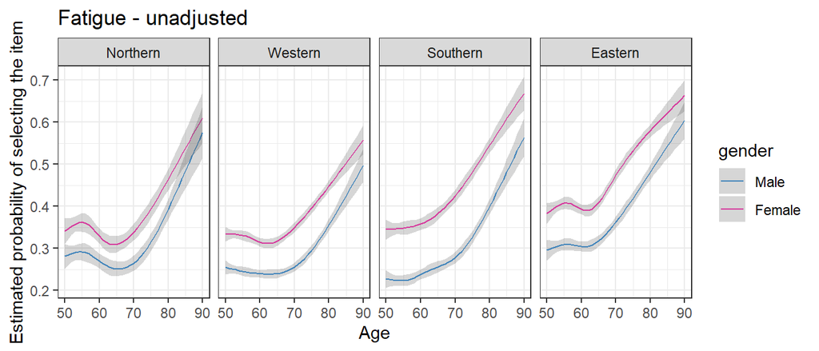

```r
i <- i+1

share.data.first.interview$y <- share.data.first.interview$euro9

my.mod2 <- glm(y ~ age1 + age2 + age3 + age4 + gender + region +
                      age1:region + age2:region + age3:region + age4:region +
                       age1:gender + age2:gender + age3:gender + age4:gender +
                       gender:region ,
                        data=share.data.first.interview, family="binomial",  x=TRUE, y=TRUE)



my.mod1 <- glm(y ~ rcspline.eval(age_int_stand, knots=Knots, inclx = TRUE)  + gender + region +
                      rcspline.eval(age_int_stand, knots=Knots, inclx = TRUE):region +
                       rcspline.eval(age_int_stand, knots=Knots, inclx = TRUE):gender +
                       gender:region ,
                        data=share.data.first.interview, family="binomial",  x=TRUE, y=TRUE)



my.pred <- predict(my.mod2, newdata=data.grid.region, se.fit = TRUE, type="response")


my.pred.all <- cbind.data.frame(data.grid.region, my.pred)
my.pred.all$item <- eurod_items[i]

#saving the prediction for the items
pred.items.unadj.region <- rbind.data.frame(pred.items.unadj.region, my.pred.all)

ggplot(my.pred.all, aes(age1 + 50, fit, color=gender)) + geom_line() + facet_wrap(region~., ncol=4) + labs(x="Age", y="Estimated probability of selecting the item") + scale_color_manual(values=c("#4699dd","#ff3db7" )) + ggtitle(paste(eurod_items[i], "- unadjusted")) + theme_bw()  +
   geom_ribbon(aes(ymin = fit - 1.96*se.fit, ymax = fit + 1.96*se.fit), alpha = 0.2, linetype=0)
```

```r
ggsave(paste0("eurod", i, "_region_Unadj.png"), device="png", path = "figures" , height = 4, width=10)

anova(my.mod1, test="Chi")
```

```
## Analysis of Deviance Table
##
## Model: binomial, link: logit
##
## Response: y
##
## Terms added sequentially (first to last)
##
##
##                                                                  Df Deviance
## NULL
## rcspline.eval(age_int_stand, knots = Knots, inclx = TRUE)         4     1456
## gender                                                            1     1123
## region                                                            3      598
## rcspline.eval(age_int_stand, knots = Knots, inclx = TRUE):region 12       92
## rcspline.eval(age_int_stand, knots = Knots, inclx = TRUE):gender  4        6
## gender:region                                                     3       47
##                                                                  Resid. Df
## NULL                                                                104003
## rcspline.eval(age_int_stand, knots = Knots, inclx = TRUE)           103999
## gender                                                              103998
## region                                                              103995
## rcspline.eval(age_int_stand, knots = Knots, inclx = TRUE):region    103983
## rcspline.eval(age_int_stand, knots = Knots, inclx = TRUE):gender    103979
## gender:region                                                       103976
##                                                                  Resid. Dev
## NULL                                                                 133699
## rcspline.eval(age_int_stand, knots = Knots, inclx = TRUE)            132243
## gender                                                               131119
## region                                                               130521
## rcspline.eval(age_int_stand, knots = Knots, inclx = TRUE):region     130429
## rcspline.eval(age_int_stand, knots = Knots, inclx = TRUE):gender     130423
## gender:region                                                        130375
##                                                                  Pr(>Chi)
## NULL
## rcspline.eval(age_int_stand, knots = Knots, inclx = TRUE)          <2e-16 ***
## gender                                                             <2e-16 ***
## region                                                             <2e-16 ***
## rcspline.eval(age_int_stand, knots = Knots, inclx = TRUE):region    2e-14 ***
## rcspline.eval(age_int_stand, knots = Knots, inclx = TRUE):gender     0.17
## gender:region                                                       3e-10 ***
## ---
## Signif. codes:  0 '***' 0.001 '**' 0.01 '*' 0.05 '.' 0.1 ' ' 1
```

#### 2.2.9.2 Adjusted model with rcs for age

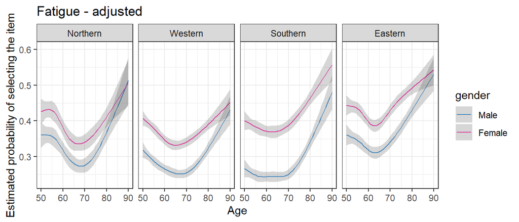

```r
my.mod1 <- glm(y ~ rcs(age_int) + gender + region +
                       rcs(age_int):region + rcs(age_int):gender + gender:region +
                       bmi_imp +  education_imp + cusmoke_imp + dis_chronic_pres +
                        pa_vig + living_arrangement,
                       data=share.data.first.interview, family="binomial",  x=TRUE, y=TRUE)


my.mod2 <- glm(y ~ age1 + age2 + age3 + age4 + gender + region +
                      age1:region + age2:region + age3:region + age4:region +
                       age1:gender + age2:gender + age3:gender + age4:gender +
                       gender:region +
                 bmi_imp + education_imp + cusmoke_imp + dis_chronic_pres +
                        pa_vig + living_arrangement,
                        data=share.data.first.interview, family="binomial",  x=TRUE, y=TRUE)

my.pred <- predict(my.mod2, newdata=data.grid.adj.region, se.fit = TRUE, type="response")


my.pred.all <- cbind.data.frame(data.grid.adj.region, my.pred)
my.pred.all$item <- eurod_items[i]

#saving the prediction for the items
pred.items.adj.region <- rbind.data.frame(pred.items.adj.region, my.pred.all)


ggplot(my.pred.all, aes(age1 + 50, fit, color=gender)) + geom_line() + facet_wrap(region~., ncol=4) + labs(x="Age", y="Estimated probability of selecting the item") + scale_color_manual(values=c("#4699dd","#ff3db7" )) + ggtitle(paste(eurod_items[i], "- adjusted")) +  theme_bw()  +
   geom_ribbon(aes(ymin = fit - 1.96*se.fit, ymax = fit + 1.96*se.fit), alpha = 0.2, linetype=0)
```

```r
ggsave(paste0("eurod", i, "_region_Adj.png"), device="png", path = "figures" , height = 4, width=10)

anova(my.mod1, test="Chi")
```

```
## Analysis of Deviance Table
##
## Model: binomial, link: logit
##
## Response: y
##
## Terms added sequentially (first to last)
##
##
##                     Df Deviance Resid. Df Resid. Dev Pr(>Chi)
## NULL                               104003     133699
## rcs(age_int)         4     1456    103999     132243  < 2e-16 ***
## gender               1     1123    103998     131119  < 2e-16 ***
## region               3      598    103995     130521  < 2e-16 ***
## bmi_imp              1      537    103994     129984  < 2e-16 ***
## education_imp        3      341    103991     129643  < 2e-16 ***
## cusmoke_imp          1      235    103990     129408  < 2e-16 ***
## dis_chronic_pres     2     2370    103988     127038  < 2e-16 ***
## pa_vig               3     1486    103985     125552  < 2e-16 ***
## living_arrangement   1       80    103984     125472  < 2e-16 ***
## rcs(age_int):region 12       74    103972     125398  6.2e-11 ***
## rcs(age_int):gender  4       13    103968     125385    0.011 *
## gender:region        3       62    103965     125324  2.4e-13 ***
## ---
## Signif. codes:  0 '***' 0.001 '**' 0.01 '*' 0.05 '.' 0.1 ' ' 1
```

```r
OR3[[i]] <- get.OR3(my.mod1, names.var = c(1:9, "BMI", "Education : Medium","Education : High", "Education : Other","Current smoking : Yes", "Chronic diseases : 1" , "Chronic diseases: 2+", "Vigorous PA : Once a week", "Vigorous PA : 1−3 times a month", "Vigorous PA : Hardly ever, or never", "Living alone : Yes", 21:39))[10:20,]

OR2[[i]] <- get.OR2(my.mod1, names.var = c(1:9, "BMI", "Education : Medium","Education : High", "Education : Other","Current smoking : Yes", "Chronic diseases : 1" , "Chronic diseases: 2+", "Vigorous PA : Once a week", "Vigorous PA : 1−3 times a month", "Vigorous PA : Hardly ever, or never", "Living alone : Yes", 21:39))[10:20,]

kable(OR3[[i]], caption=paste(eurod_items_2names[i], "- OR for the risk factors"))
```

euro9 - Fatigue - OR for the risk factors

|  | OR | 95% CI | P |
| --- | --- | --- | --- |
| BMI | 1.15 | 1.11-1.18 | <0.01 |
| Education : Medium | 0.85 | 0.83-0.88 | <0.01 |
| Education : High | 0.79 | 0.76-0.82 | <0.01 |
| Education : Other | 0.86 | 0.7-1.05 | 0.15 |
| Current smoking : Yes | 1.27 | 1.23-1.32 | <0.01 |
| Chronic diseases : 1 | 1.40 | 1.35-1.44 | <0.01 |
| Chronic diseases: 2+ | 2.32 | 2.24-2.41 | <0.01 |
| Vigorous PA : Once a week | 1.07 | 1.02-1.12 | <0.01 |
| Vigorous PA : 1-3 times a month | 1.16 | 1.1-1.22 | <0.01 |
| Vigorous PA : Hardly ever, or never | 1.81 | 1.75-1.87 | <0.01 |
| Living alone : Yes | 1.15 | 1.12-1.19 | <0.01 |

### 2.2.10 Item 10- Concentration

#### 2.2.10.1 Unadjusted model with rcs for age

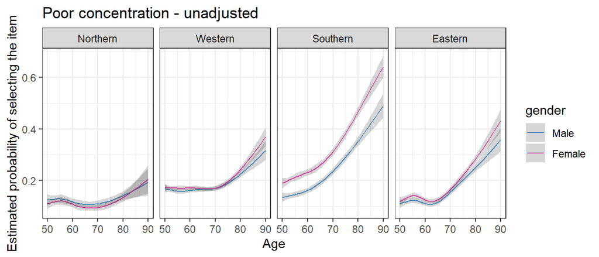

```r
i <- i+1

share.data.first.interview$y <- share.data.first.interview$euro10

my.mod2 <- glm(y ~ age1 + age2 + age3 + age4 + gender + region +
                      age1:region + age2:region + age3:region + age4:region +
                       age1:gender + age2:gender + age3:gender + age4:gender +
                       gender:region ,
                        data=share.data.first.interview, family="binomial",  x=TRUE, y=TRUE)



my.mod1 <- glm(y ~ rcspline.eval(age_int_stand, knots=Knots, inclx = TRUE)  + gender + region +
                      rcspline.eval(age_int_stand, knots=Knots, inclx = TRUE):region +
                       rcspline.eval(age_int_stand, knots=Knots, inclx = TRUE):gender +
                       gender:region ,
                        data=share.data.first.interview, family="binomial",  x=TRUE, y=TRUE)



my.pred <- predict(my.mod2, newdata=data.grid.region, se.fit = TRUE, type="response")


my.pred.all <- cbind.data.frame(data.grid.region, my.pred)
my.pred.all$item <- eurod_items[i]

#saving the prediction for the items
pred.items.unadj.region <- rbind.data.frame(pred.items.unadj.region, my.pred.all)

ggplot(my.pred.all, aes(age1 + 50, fit, color=gender)) + geom_line() + facet_wrap(region~., ncol=4) + labs(x="Age", y="Estimated probability of selecting the item") + scale_color_manual(values=c("#4699dd","#ff3db7" )) + ggtitle(paste(eurod_items[i], "- unadjusted")) + theme_bw()  +
   geom_ribbon(aes(ymin = fit - 1.96*se.fit, ymax = fit + 1.96*se.fit), alpha = 0.2, linetype=0)
```

```r
ggsave(paste0("eurod", i, "_region_Unadj.png"), device="png", path = "figures" , height = 4, width=10)

anova(my.mod1, test="Chi")
```

```
## Analysis of Deviance Table
##
## Model: binomial, link: logit
##
## Response: y
##
## Terms added sequentially (first to last)
##
##
##                                                                  Df Deviance
## NULL
## rcspline.eval(age_int_stand, knots = Knots, inclx = TRUE)         4     1340
## gender                                                            1       89
## region                                                            3     1089
## rcspline.eval(age_int_stand, knots = Knots, inclx = TRUE):region 12      328
## rcspline.eval(age_int_stand, knots = Knots, inclx = TRUE):gender  4        6
## gender:region                                                     3      110
##                                                                  Resid. Df
## NULL                                                                103848
## rcspline.eval(age_int_stand, knots = Knots, inclx = TRUE)           103844
## gender                                                              103843
## region                                                              103840
## rcspline.eval(age_int_stand, knots = Knots, inclx = TRUE):region    103828
## rcspline.eval(age_int_stand, knots = Knots, inclx = TRUE):gender    103824
## gender:region                                                       103821
##                                                                  Resid. Dev
## NULL                                                                  98056
## rcspline.eval(age_int_stand, knots = Knots, inclx = TRUE)             96716
## gender                                                                96627
## region                                                                95538
## rcspline.eval(age_int_stand, knots = Knots, inclx = TRUE):region      95210
## rcspline.eval(age_int_stand, knots = Knots, inclx = TRUE):gender      95204
## gender:region                                                         95094
##                                                                  Pr(>Chi)
## NULL
## rcspline.eval(age_int_stand, knots = Knots, inclx = TRUE)          <2e-16 ***
## gender                                                             <2e-16 ***
## region                                                             <2e-16 ***
## rcspline.eval(age_int_stand, knots = Knots, inclx = TRUE):region   <2e-16 ***
## rcspline.eval(age_int_stand, knots = Knots, inclx = TRUE):gender     0.18
## gender:region                                                      <2e-16 ***
## ---
## Signif. codes:  0 '***' 0.001 '**' 0.01 '*' 0.05 '.' 0.1 ' ' 1
```

#### 2.2.10.2 Adjusted model with rcs for age

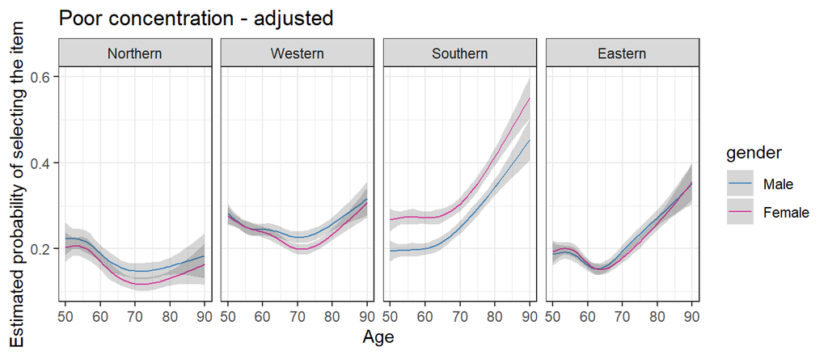

```r
my.mod1 <- glm(y ~ rcs(age_int) + gender + region +
                       rcs(age_int):region + rcs(age_int):gender + gender:region +
                       bmi_imp +  education_imp + cusmoke_imp + dis_chronic_pres +
                        pa_vig + living_arrangement,
                       data=share.data.first.interview, family="binomial",  x=TRUE, y=TRUE)


my.mod2 <- glm(y ~ age1 + age2 + age3 + age4 + gender + region +
                      age1:region + age2:region + age3:region + age4:region +
                       age1:gender + age2:gender + age3:gender + age4:gender +
                       gender:region +
                 bmi_imp + education_imp + cusmoke_imp + dis_chronic_pres +
                        pa_vig + living_arrangement,
                        data=share.data.first.interview, family="binomial",  x=TRUE, y=TRUE)

my.pred <- predict(my.mod2, newdata=data.grid.adj.region, se.fit = TRUE, type="response")


my.pred.all <- cbind.data.frame(data.grid.adj.region, my.pred)
my.pred.all$item <- eurod_items[i]

#saving the prediction for the items
pred.items.adj.region <- rbind.data.frame(pred.items.adj.region, my.pred.all)


ggplot(my.pred.all, aes(age1 + 50, fit, color=gender)) + geom_line() + facet_wrap(region~., ncol=4) + labs(x="Age", y="Estimated probability of selecting the item") + scale_color_manual(values=c("#4699dd","#ff3db7" )) + ggtitle(paste(eurod_items[i], "- adjusted")) +  theme_bw()  +
   geom_ribbon(aes(ymin = fit - 1.96*se.fit, ymax = fit + 1.96*se.fit), alpha = 0.2, linetype=0)
```

```r
ggsave(paste0("eurod", i, "_region_Adj.png"), device="png", path = "figures" , height = 4, width=10)

anova(my.mod1, test="Chi")
```

```
## Analysis of Deviance Table
##
## Model: binomial, link: logit
##
## Response: y
##
## Terms added sequentially (first to last)
##
##
##                     Df Deviance Resid. Df Resid. Dev Pr(>Chi)
## NULL                               103848      98056
## rcs(age_int)         4     1340    103844      96716   <2e-16 ***
## gender               1       89    103843      96627   <2e-16 ***
## region               3     1089    103840      95538   <2e-16 ***
## bmi_imp              1       86    103839      95452   <2e-16 ***
## education_imp        3     1521    103836      93931   <2e-16 ***
## cusmoke_imp          1        1    103835      93930    0.424
## dis_chronic_pres     2      700    103833      93231   <2e-16 ***
## pa_vig               3      536    103830      92694   <2e-16 ***
## living_arrangement   1      124    103829      92571   <2e-16 ***
## rcs(age_int):region 12      328    103817      92243   <2e-16 ***
## rcs(age_int):gender  4        9    103813      92234    0.073 .
## gender:region        3      129    103810      92105   <2e-16 ***
## ---
## Signif. codes:  0 '***' 0.001 '**' 0.01 '*' 0.05 '.' 0.1 ' ' 1
```

```r
OR3[[i]] <- get.OR3(my.mod1, names.var = c(1:9, "BMI", "Education : Medium","Education : High", "Education : Other","Current smoking : Yes", "Chronic diseases : 1" , "Chronic diseases: 2+", "Vigorous PA : Once a week", "Vigorous PA : 1−3 times a month", "Vigorous PA : Hardly ever, or never", "Living alone : Yes", 21:39))[10:20,]

OR2[[i]] <- get.OR2(my.mod1, names.var = c(1:9, "BMI", "Education : Medium","Education : High", "Education : Other","Current smoking : Yes", "Chronic diseases : 1" , "Chronic diseases: 2+", "Vigorous PA : Once a week", "Vigorous PA : 1−3 times a month", "Vigorous PA : Hardly ever, or never", "Living alone : Yes", 21:39))[10:20,]

kable(OR3[[i]], caption=paste(eurod_items_2names[i], "- OR for the risk factors"))
```

euro10 - Poor concentration - OR for the risk factors

|  | OR | 95% CI | P |
| --- | --- | --- | --- |
| BMI | 0.96 | 0.92-1 | 0.03 |
| Education : Medium | 0.60 | 0.58-0.63 | <0.01 |
| Education : High | 0.42 | 0.4-0.45 | <0.01 |
| Education : Other | 0.94 | 0.75-1.18 | 0.61 |
| Current smoking : Yes | 0.99 | 0.95-1.03 | 0.64 |
| Chronic diseases : 1 | 1.22 | 1.17-1.27 | <0.01 |
| Chronic diseases: 2+ | 1.71 | 1.63-1.79 | <0.01 |
| Vigorous PA : Once a week | 1.00 | 0.95-1.06 | 0.93 |
| Vigorous PA : 1-3 times a month | 1.12 | 1.05-1.19 | <0.01 |
| Vigorous PA : Hardly ever, or never | 1.53 | 1.47-1.6 | <0.01 |
| Living alone : Yes | 1.23 | 1.19-1.28 | <0.01 |

### 2.2.11 Item 11 - Enjoyment

#### 2.2.11.1 Unadjusted model with rcs for age

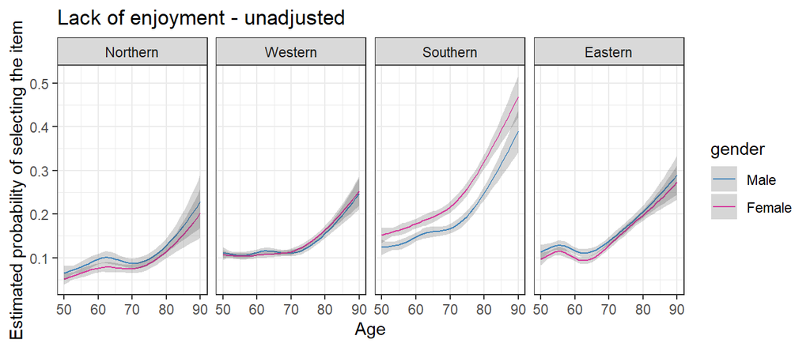

```r
i <- i+1

share.data.first.interview$y <- share.data.first.interview$euro11

my.mod2 <- glm(y ~ age1 + age2 + age3 + age4 + gender + region +
                      age1:region + age2:region + age3:region + age4:region +
                       age1:gender + age2:gender + age3:gender + age4:gender +
                       gender:region ,
                        data=share.data.first.interview, family="binomial",  x=TRUE, y=TRUE)



my.mod1 <- glm(y ~ rcspline.eval(age_int_stand, knots=Knots, inclx = TRUE)  + gender + region +
                      rcspline.eval(age_int_stand, knots=Knots, inclx = TRUE):region +
                       rcspline.eval(age_int_stand, knots=Knots, inclx = TRUE):gender +
                       gender:region ,
                        data=share.data.first.interview, family="binomial",  x=TRUE, y=TRUE)



my.pred <- predict(my.mod2, newdata=data.grid.region, se.fit = TRUE, type="response")


my.pred.all <- cbind.data.frame(data.grid.region, my.pred)
my.pred.all$item <- eurod_items[i]

#saving the prediction for the items
pred.items.unadj.region <- rbind.data.frame(pred.items.unadj.region, my.pred.all)

ggplot(my.pred.all, aes(age1 + 50, fit, color=gender)) + geom_line() + facet_wrap(region~., ncol=4) + labs(x="Age", y="Estimated probability of selecting the item") + scale_color_manual(values=c("#4699dd","#ff3db7" )) + ggtitle(paste(eurod_items[i], "- unadjusted")) + theme_bw()  +
   geom_ribbon(aes(ymin = fit - 1.96*se.fit, ymax = fit + 1.96*se.fit), alpha = 0.2, linetype=0)
```

```r
ggsave(paste0("eurod", i, "_region_Unadj.png"), device="png", path = "figures" , height = 4, width=10)

anova(my.mod1, test="Chi")
```

```
## Analysis of Deviance Table
##
## Model: binomial, link: logit
##
## Response: y
##
## Terms added sequentially (first to last)
##
##
##                                                                  Df Deviance
## NULL
## rcspline.eval(age_int_stand, knots = Knots, inclx = TRUE)         4      820
## gender                                                            1        3
## region                                                            3      838
## rcspline.eval(age_int_stand, knots = Knots, inclx = TRUE):region 12       77
## rcspline.eval(age_int_stand, knots = Knots, inclx = TRUE):gender  4        8
## gender:region                                                     3       84
##                                                                  Resid. Df
## NULL                                                                103947
## rcspline.eval(age_int_stand, knots = Knots, inclx = TRUE)           103943
## gender                                                              103942
## region                                                              103939
## rcspline.eval(age_int_stand, knots = Knots, inclx = TRUE):region    103927
## rcspline.eval(age_int_stand, knots = Knots, inclx = TRUE):gender    103923
## gender:region                                                       103920
##                                                                  Resid. Dev
## NULL                                                                  81359
## rcspline.eval(age_int_stand, knots = Knots, inclx = TRUE)             80539
## gender                                                                80536
## region                                                                79698
## rcspline.eval(age_int_stand, knots = Knots, inclx = TRUE):region      79621
## rcspline.eval(age_int_stand, knots = Knots, inclx = TRUE):gender      79613
## gender:region                                                         79529
##                                                                  Pr(>Chi)
## NULL
## rcspline.eval(age_int_stand, knots = Knots, inclx = TRUE)         < 2e-16 ***
## gender                                                              0.092 .
## region                                                            < 2e-16 ***
## rcspline.eval(age_int_stand, knots = Knots, inclx = TRUE):region  1.6e-11 ***
## rcspline.eval(age_int_stand, knots = Knots, inclx = TRUE):gender    0.092 .
## gender:region                                                     < 2e-16 ***
## ---
## Signif. codes:  0 '***' 0.001 '**' 0.01 '*' 0.05 '.' 0.1 ' ' 1
```

#### 2.2.11.2 Adjusted model with rcs for age

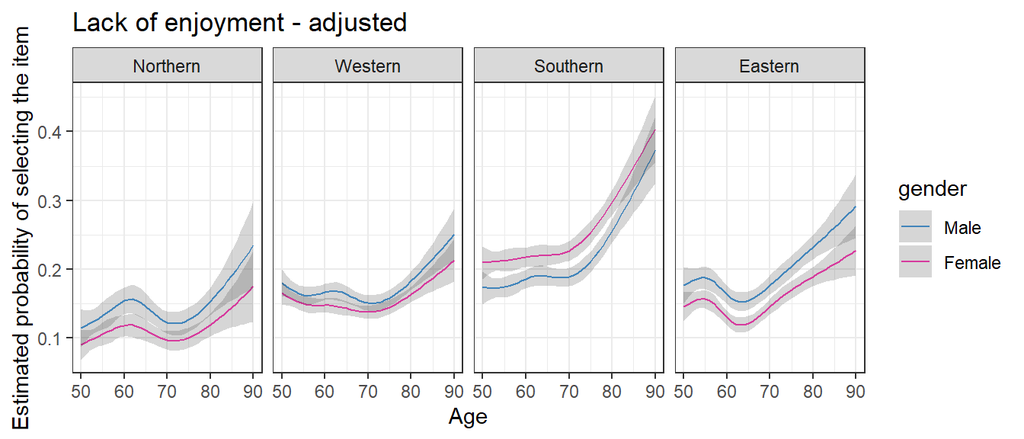

```r
my.mod1 <- glm(y ~ rcs(age_int) + gender + region +
                       rcs(age_int):region + rcs(age_int):gender + gender:region +
                       bmi_imp +  education_imp + cusmoke_imp + dis_chronic_pres +
                        pa_vig + living_arrangement,
                       data=share.data.first.interview, family="binomial",  x=TRUE, y=TRUE)


my.mod2 <- glm(y ~ age1 + age2 + age3 + age4 + gender + region +
                      age1:region + age2:region + age3:region + age4:region +
                       age1:gender + age2:gender + age3:gender + age4:gender +
                       gender:region +
                 bmi_imp + education_imp + cusmoke_imp + dis_chronic_pres +
                        pa_vig + living_arrangement,
                        data=share.data.first.interview, family="binomial",  x=TRUE, y=TRUE)

my.pred <- predict(my.mod2, newdata=data.grid.adj.region, se.fit = TRUE, type="response")


my.pred.all <- cbind.data.frame(data.grid.adj.region, my.pred)
my.pred.all$item <- eurod_items[i]

#saving the prediction for the items
pred.items.adj.region <- rbind.data.frame(pred.items.adj.region, my.pred.all)


ggplot(my.pred.all, aes(age1 + 50, fit, color=gender)) + geom_line() + facet_wrap(region~., ncol=4) + labs(x="Age", y="Estimated probability of selecting the item") + scale_color_manual(values=c("#4699dd","#ff3db7" )) + ggtitle(paste(eurod_items[i], "- adjusted")) +  theme_bw()  +
   geom_ribbon(aes(ymin = fit - 1.96*se.fit, ymax = fit + 1.96*se.fit), alpha = 0.2, linetype=0)
```

```r
ggsave(paste0("eurod", i, "_region_Adj.png"), device="png", path = "figures" , height = 4, width=10)

anova(my.mod1, test="Chi")
```

```
## Analysis of Deviance Table
##
## Model: binomial, link: logit
##
## Response: y
##
## Terms added sequentially (first to last)
##
##
##                     Df Deviance Resid. Df Resid. Dev Pr(>Chi)
## NULL                               103947      81359
## rcs(age_int)         4      820    103943      80539  < 2e-16 ***
## gender               1        3    103942      80536    0.092 .
## region               3      838    103939      79698  < 2e-16 ***
## bmi_imp              1       32    103938      79666  1.3e-08 ***
## education_imp        3      579    103935      79087  < 2e-16 ***
## cusmoke_imp          1       56    103934      79030  5.9e-14 ***
## dis_chronic_pres     2      252    103932      78778  < 2e-16 ***
## pa_vig               3      709    103929      78070  < 2e-16 ***
## living_arrangement   1       92    103928      77978  < 2e-16 ***
## rcs(age_int):region 12       78    103916      77900  1.0e-11 ***
## rcs(age_int):gender  4        2    103912      77898    0.789
## gender:region        3      104    103909      77794  < 2e-16 ***
## ---
## Signif. codes:  0 '***' 0.001 '**' 0.01 '*' 0.05 '.' 0.1 ' ' 1
```

```r
OR3[[i]] <- get.OR3(my.mod1, names.var = c(1:9, "BMI", "Education : Medium","Education : High", "Education : Other","Current smoking : Yes", "Chronic diseases : 1" , "Chronic diseases: 2+", "Vigorous PA : Once a week", "Vigorous PA : 1−3 times a month", "Vigorous PA : Hardly ever, or never", "Living alone : Yes", 21:39))[10:20,]

OR2[[i]] <- get.OR2(my.mod1, names.var = c(1:9, "BMI", "Education : Medium","Education : High", "Education : Other","Current smoking : Yes", "Chronic diseases : 1" , "Chronic diseases: 2+", "Vigorous PA : Once a week", "Vigorous PA : 1−3 times a month", "Vigorous PA : Hardly ever, or never", "Living alone : Yes", 21:39))[10:20,]

kable(OR3[[i]], caption=paste(eurod_items_2names[i], "- OR for the risk factors"))
```

euro11 - Lack of enjoyment - OR for the risk factors

|  | OR | 95% CI | P |
| --- | --- | --- | --- |
| BMI | 0.98 | 0.94-1.02 | 0.35 |
| Education : Medium | 0.76 | 0.73-0.79 | <0.01 |
| Education : High | 0.55 | 0.52-0.59 | <0.01 |
| Education : Other | 0.87 | 0.66-1.14 | 0.32 |
| Current smoking : Yes | 1.16 | 1.1-1.21 | <0.01 |
| Chronic diseases : 1 | 1.10 | 1.05-1.15 | <0.01 |
| Chronic diseases: 2+ | 1.37 | 1.3-1.44 | <0.01 |
| Vigorous PA : Once a week | 1.07 | 1-1.14 | 0.04 |
| Vigorous PA : 1-3 times a month | 1.18 | 1.1-1.27 | <0.01 |
| Vigorous PA : Hardly ever, or never | 1.77 | 1.69-1.85 | <0.01 |
| Living alone : Yes | 1.22 | 1.17-1.28 | <0.01 |

### 2.2.12 Item 12 - Tearfullness

#### 2.2.12.1 Unadjusted model with rcs for age

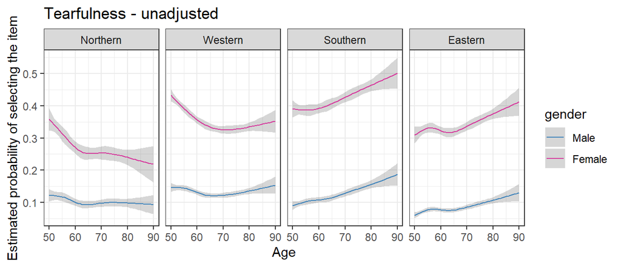

```r
i <- i+1

share.data.first.interview$y <- share.data.first.interview$euro12

my.mod2 <- glm(y ~ age1 + age2 + age3 + age4 + gender + region +
                      age1:region + age2:region + age3:region + age4:region +
                       age1:gender + age2:gender + age3:gender + age4:gender +
                       gender:region ,
                        data=share.data.first.interview, family="binomial",  x=TRUE, y=TRUE)



my.mod1 <- glm(y ~ rcspline.eval(age_int_stand, knots=Knots, inclx = TRUE)  + gender + region +
                      rcspline.eval(age_int_stand, knots=Knots, inclx = TRUE):region +
                       rcspline.eval(age_int_stand, knots=Knots, inclx = TRUE):gender +
                       gender:region ,
                        data=share.data.first.interview, family="binomial",  x=TRUE, y=TRUE)



my.pred <- predict(my.mod2, newdata=data.grid.region, se.fit = TRUE, type="response")


my.pred.all <- cbind.data.frame(data.grid.region, my.pred)
my.pred.all$item <- eurod_items[i]

#saving the prediction for the items
pred.items.unadj.region <- rbind.data.frame(pred.items.unadj.region, my.pred.all)

ggplot(my.pred.all, aes(age1 + 50, fit, color=gender)) + geom_line() + facet_wrap(region~., ncol=4) + labs(x="Age", y="Estimated probability of selecting the item") + scale_color_manual(values=c("#4699dd","#ff3db7" )) + ggtitle(paste(eurod_items[i], "- unadjusted")) + theme_bw()  +
   geom_ribbon(aes(ymin = fit - 1.96*se.fit, ymax = fit + 1.96*se.fit), alpha = 0.2, linetype=0)
```

```r
ggsave(paste0("eurod", i, "_region_Unadj.png"), device="png", path = "figures" , height = 4, width=10)

anova(my.mod1, test="Chi")
```

```
## Analysis of Deviance Table
##
## Model: binomial, link: logit
##
## Response: y
##
## Terms added sequentially (first to last)
##
##
##                                                                  Df Deviance
## NULL
## rcspline.eval(age_int_stand, knots = Knots, inclx = TRUE)         4      148
## gender                                                            1     8689
## region                                                            3      404
## rcspline.eval(age_int_stand, knots = Knots, inclx = TRUE):region 12      221
## rcspline.eval(age_int_stand, knots = Knots, inclx = TRUE):gender  4       12
## gender:region                                                     3      159
##                                                                  Resid. Df
## NULL                                                                103982
## rcspline.eval(age_int_stand, knots = Knots, inclx = TRUE)           103978
## gender                                                              103977
## region                                                              103974
## rcspline.eval(age_int_stand, knots = Knots, inclx = TRUE):region    103962
## rcspline.eval(age_int_stand, knots = Knots, inclx = TRUE):gender    103958
## gender:region                                                       103955
##                                                                  Resid. Dev
## NULL                                                                 115811
## rcspline.eval(age_int_stand, knots = Knots, inclx = TRUE)            115663
## gender                                                               106974
## region                                                               106570
## rcspline.eval(age_int_stand, knots = Knots, inclx = TRUE):region     106349
## rcspline.eval(age_int_stand, knots = Knots, inclx = TRUE):gender     106337
## gender:region                                                        106178
##                                                                  Pr(>Chi)
## NULL
## rcspline.eval(age_int_stand, knots = Knots, inclx = TRUE)          <2e-16 ***
## gender                                                             <2e-16 ***
## region                                                             <2e-16 ***
## rcspline.eval(age_int_stand, knots = Knots, inclx = TRUE):region   <2e-16 ***
## rcspline.eval(age_int_stand, knots = Knots, inclx = TRUE):gender    0.016 *
## gender:region                                                      <2e-16 ***
## ---
## Signif. codes:  0 '***' 0.001 '**' 0.01 '*' 0.05 '.' 0.1 ' ' 1
```

#### 2.2.12.2 Adjusted model with rcs for age

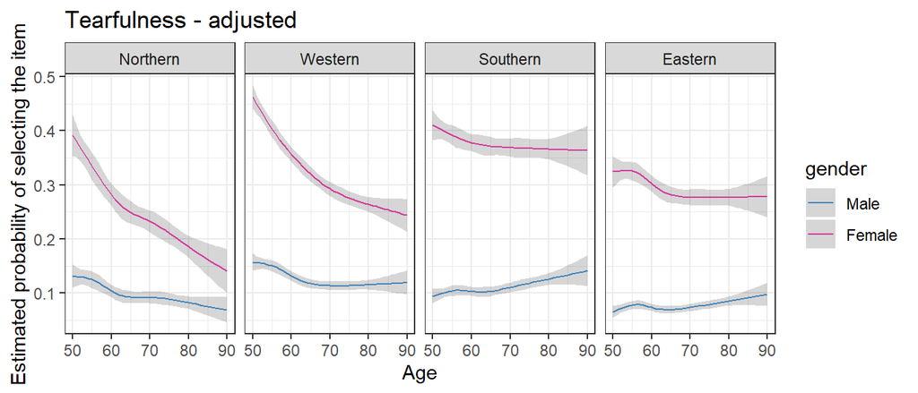

```r
my.mod1 <- glm(y ~ rcs(age_int) + gender + region +
                       rcs(age_int):region + rcs(age_int):gender + gender:region +
                       bmi_imp +  education_imp + cusmoke_imp + dis_chronic_pres +
                        pa_vig + living_arrangement,
                       data=share.data.first.interview, family="binomial",  x=TRUE, y=TRUE)


my.mod2 <- glm(y ~ age1 + age2 + age3 + age4 + gender + region +
                      age1:region + age2:region + age3:region + age4:region +
                       age1:gender + age2:gender + age3:gender + age4:gender +
                       gender:region +
                 bmi_imp + education_imp + cusmoke_imp + dis_chronic_pres +
                        pa_vig + living_arrangement,
                        data=share.data.first.interview, family="binomial",  x=TRUE, y=TRUE)

my.pred <- predict(my.mod2, newdata=data.grid.adj.region, se.fit = TRUE, type="response")


my.pred.all <- cbind.data.frame(data.grid.adj.region, my.pred)
my.pred.all$item <- eurod_items[i]

#saving the prediction for the items
pred.items.adj.region <- rbind.data.frame(pred.items.adj.region, my.pred.all)


ggplot(my.pred.all, aes(age1 + 50, fit, color=gender)) + geom_line() + facet_wrap(region~., ncol=4) + labs(x="Age", y="Estimated probability of selecting the item") + scale_color_manual(values=c("#4699dd","#ff3db7" )) + ggtitle(paste(eurod_items[i], "- adjusted")) +  theme_bw()  +
   geom_ribbon(aes(ymin = fit - 1.96*se.fit, ymax = fit + 1.96*se.fit), alpha = 0.2, linetype=0)
```

```r
ggsave(paste0("eurod", i, "_region_Adj.png"), device="png", path = "figures" , height = 4, width=10)

anova(my.mod1, test="Chi")
```

```
## Analysis of Deviance Table
##
## Model: binomial, link: logit
##
## Response: y
##
## Terms added sequentially (first to last)
##
##
##                     Df Deviance Resid. Df Resid. Dev Pr(>Chi)
## NULL                               103982     115811
## rcs(age_int)         4      148    103978     115663  < 2e-16 ***
## gender               1     8689    103977     106974  < 2e-16 ***
## region               3      404    103974     106570  < 2e-16 ***
## bmi_imp              1      311    103973     106260  < 2e-16 ***
## education_imp        3      223    103970     106036  < 2e-16 ***
## cusmoke_imp          1        5    103969     106031    0.023 *
## dis_chronic_pres     2      760    103967     105271  < 2e-16 ***
## pa_vig               3      144    103964     105127  < 2e-16 ***
## living_arrangement   1      443    103963     104684  < 2e-16 ***
## rcs(age_int):region 12      180    103951     104504  < 2e-16 ***
## rcs(age_int):gender  4       49    103947     104455  7.4e-10 ***
## gender:region        3      135    103944     104320  < 2e-16 ***
## ---
## Signif. codes:  0 '***' 0.001 '**' 0.01 '*' 0.05 '.' 0.1 ' ' 1
```

```r
OR3[[i]] <- get.OR3(my.mod1, names.var = c(1:9, "BMI", "Education : Medium","Education : High", "Education : Other","Current smoking : Yes", "Chronic diseases : 1" , "Chronic diseases: 2+", "Vigorous PA : Once a week", "Vigorous PA : 1−3 times a month", "Vigorous PA : Hardly ever, or never", "Living alone : Yes", 21:39))[10:20,]

OR2[[i]] <- get.OR2(my.mod1, names.var = c(1:9, "BMI", "Education : Medium","Education : High", "Education : Other","Current smoking : Yes", "Chronic diseases : 1" , "Chronic diseases: 2+", "Vigorous PA : Once a week", "Vigorous PA : 1−3 times a month", "Vigorous PA : Hardly ever, or never", "Living alone : Yes", 21:39))[10:20,]

kable(OR3[[i]], caption=paste(eurod_items_2names[i], "- OR for the risk factors"))
```

euro12 - Tearfulness - OR for the risk factors

|  | OR | 95% CI | P |
| --- | --- | --- | --- |
| BMI | 1.15 | 1.11-1.19 | <0.01 |
| Education : Medium | 0.82 | 0.79-0.85 | <0.01 |
| Education : High | 0.78 | 0.74-0.81 | <0.01 |
| Education : Other | 0.96 | 0.77-1.2 | 0.7 |
| Current smoking : Yes | 1.01 | 0.97-1.05 | 0.7 |
| Chronic diseases : 1 | 1.25 | 1.2-1.29 | <0.01 |
| Chronic diseases: 2+ | 1.75 | 1.67-1.83 | <0.01 |
| Vigorous PA : Once a week | 0.94 | 0.89-0.98 | <0.01 |
| Vigorous PA : 1-3 times a month | 0.94 | 0.89-1 | 0.04 |
| Vigorous PA : Hardly ever, or never | 1.17 | 1.13-1.21 | <0.01 |
| Living alone : Yes | 1.44 | 1.39-1.49 | <0.01 |

### 2.2.13 Summary of the results

The figure shows the estimated OR from each of the single item models with the 95% CI.

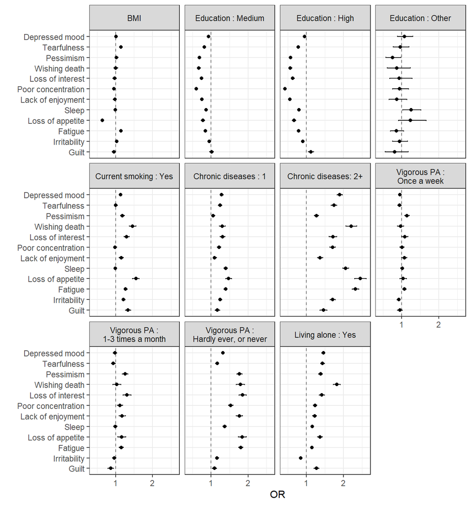

```r
p <- ggplot(pred.items.adj.region, aes(age1 + 50, fit, color=gender)) + geom_line() + facet_grid(item~region) + labs(x="Age", y="Estimated probability of selecting the item") + scale_color_manual(values=c("#4699dd","#ff3db7" )) + ggtitle("Probability of selecting items - adjusted") +  theme_bw()  + geom_ribbon(aes(ymin = fit - 1.96*se.fit, ymax = fit + 1.96*se.fit), alpha = 0.2, linetype=0)


ggsave(paste0("items_region_Adj_all.png"), plot = p, device="png", path = "figures" , scale=1.5)



p <- ggplot(pred.items.unadj.region, aes(age1 + 50, fit, color=gender)) + geom_line() + facet_grid(item~region) + labs(x="Age", y="Estimated probability of selecting the item") + scale_color_manual(values=c("#4699dd","#ff3db7" )) + ggtitle("Probability of selecting items - unadjusted") +  theme_bw()  + geom_ribbon(aes(ymin = fit - 1.96*se.fit, ymax = fit + 1.96*se.fit), alpha = 0.2, linetype=0)


ggsave(paste0("items_region_UnAdj_all.png"), device="png", plot=p, path = "figures" , scale = 1.5)

# save the results in a file
saveRDS(pred.items.adj.region, file="figures/predItemsAdjRegion.rds")

saveRDS(pred.items.unadj.region, file="figures/predItemsUnadjRegion.rds")

saveRDS(OR2, file="figures/OR2.rds")


saveRDS(OR3, file="figures/OR3.rds")
# to read
# OR3 <- readRDS("figures/OR3.rds")


OR2 <- readRDS("figures/OR2.rds")

OR2.df <- do.call(rbind.data.frame, OR2)
OR2.df$eurod_item <- rep(eurod_items, each=11)
OR2.df$eurod_labs <- rep(eurod_items_labs, each=11)
OR2.df$eurod_2names <- rep(eurod_items_2names, each=11)
OR2.df$eurod <- rep(paste0("euro",1:12), each=11)
OR2.df$var_name <-rep(c("BMI", "Education : Medium","Education : High", "Education : Other","Current smoking : Yes", "Chronic diseases : 1" , "Chronic diseases: 2+", "Vigorous PA :\nOnce a week", "Vigorous PA :\n1−3 times a month", "Vigorous PA :\nHardly ever, or never", "Living alone : Yes"))

OR2.df$var_name <- factor(OR2.df$var_name, levels = c("BMI", "Education : Medium","Education : High", "Education : Other","Current smoking : Yes", "Chronic diseases : 1" , "Chronic diseases: 2+", "Vigorous PA :\nOnce a week", "Vigorous PA :\n1−3 times a month", "Vigorous PA :\nHardly ever, or never", "Living alone : Yes"))



OR2.df$eurod_item <- factor(OR2.df$eurod_item, levels = c("Depressed mood",
                                                        "Tearfulness",
                                                        "Pessimism",
                                                        "Wishing death",
                                                     "Loss of interest",
                                                        "Poor concentration",
                                                        "Lack of enjoyment",
                                                        "Sleep",
                                                        "Loss of appetite",
                                                        "Fatigue",
                                                        "Irritability",
                                                        "Guilt"
                                                  )
                                                        )

# plot of the OR
ggplot(OR2.df, aes(x=OR, y=eurod_item, xmin=`95\\% CI LL` , xmax =`95\\% CI UL` ))+ geom_point() + facet_wrap(var_name~., nrow=3) + geom_vline(xintercept=1, color="black", linetype="dashed", alpha=.5) + geom_errorbarh(height=.1) + labs(y="") + scale_y_discrete(limits = rev) + theme_bw()
```

```r
ggsave(paste0("Items_RiskFactors.png"), device="png", path = "figures" , scale=1.5)


OR3 <- readRDS("figures/OR3.rds")

OR3.df <- do.call(cbind.data.frame, OR3)
items.table.latex <- kable(OR3.df, format="latex", caption="Risk factors in the items analysis")



saveRDS(pred.items.adj.region, file="out/predItemsAdjRegion.rds")
```

The estimated association between age and probability of depression (at fixed values of the other covariates) obtained from the adjusted models is shown in the two figures below.

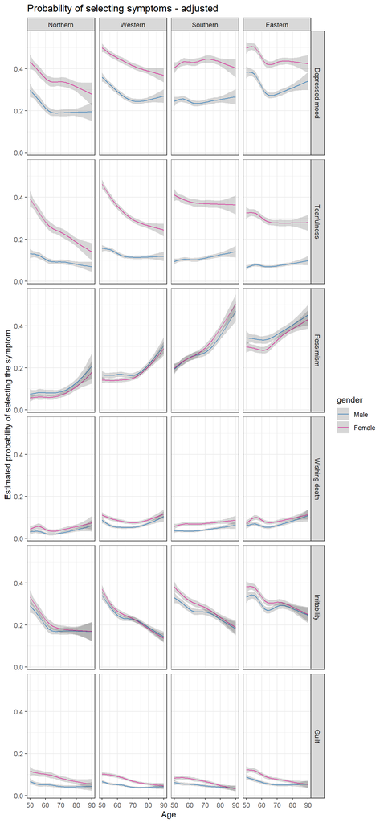

```r
pred.items.adj.region <-readRDS(file="out/predItemsAdjRegion.rds")


pred.items.adj.region$item <- factor(pred.items.adj.region$item, levels = c("Depressed mood",
                                                        "Tearfulness",
                                                        "Pessimism",
                                                        "Wishing death",
                                                     "Loss of interest",
                                                        "Poor concentration",
                                                        "Lack of enjoyment",
                                                        "Sleep",
                                                        "Loss of appetite",
                                                        "Fatigue",
                                                        "Irritability",
                                                        "Guilt"
                                                  )
                                                        )

pred.items.adj.region %>% filter(item=="Depressed mood" | item =="Tearfulness" | item=="Pessimism" | item == "Wishing death" |
                                   item == "Irritability" | item == "Guilt") %>% mutate(item = factor(item, levels = c(
                                     "Depressed mood",
                                                        "Tearfulness",
                                                        "Pessimism",
                                                        "Wishing death","Irritability",
                                                        "Guilt" ) )) %>%

# plot of the association between age and probability of depression
ggplot(aes(age1 + 50, fit, color=gender)) + geom_line() + facet_grid(item~region) + labs(x="Age", y="Estimated probability of selecting the symptom") + scale_color_manual(values=c("#4699dd","#ff3db7" )) + ggtitle("Probability of selecting symptoms - adjusted") +  theme_bw()  + geom_ribbon(aes(ymin = fit - 1.96*se.fit, ymax = fit + 1.96*se.fit), alpha = 0.2, linetype=0)
```

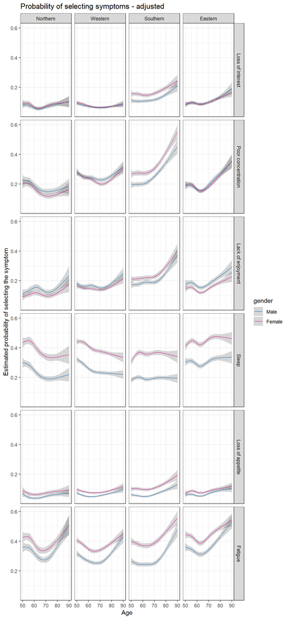

```r
ggsave(paste0("itemsA_region_Adj_all.png"), device="png", path = "figures" , scale=1.5)




pred.items.adj.region %>% filter(item!="Depressed mood" & item !="Tearfulness" & item!="Pessimism" & item != "Wishing death" &
                                   item != "Irritability" & item != "Guilt") %>% mutate(item = factor(item, levels = c(

                                     "Loss of interest",
                                                        "Poor concentration",
                                                        "Lack of enjoyment",
                                                        "Sleep",
                                                        "Loss of appetite",
                                                        "Fatigue"  ) )) %>%
ggplot(aes(age1 + 50, fit, color=gender)) + geom_line() + facet_grid(item~region) + labs(x="Age", y="Estimated probability of selecting the symptom") + scale_color_manual(values=c("#4699dd","#ff3db7" )) + ggtitle("Probability of selecting symptoms - adjusted") +  theme_bw()  + geom_ribbon(aes(ymin = fit - 1.96*se.fit, ymax = fit + 1.96*se.fit), alpha = 0.2, linetype=0)
```

```r
ggsave(paste0("itemsB_region_Adj_all.png"), device="png", path = "figures" , scale=1.5)
```